# OpenFDA-Run-on-python-2

```python
import warnings; warnings.simplefilter('ignore')
```

```python
#https://open.fda.gov/drug/event/reference/
```

```python
import xlsxwriter
import pandas as pd
#import pyodbc
import numpy as np
import matplotlib.pyplot as plt
from pyquery import PyQuery as pq
import re
import seaborn as sns
```

```python
%matplotlib inline
#plt.style.use('seaborn-white')
#plt.rcParams.update({'font.size': 14})
```

# Read in data

### 40 files per year with 100 entries each between 2012 and 2017

First making the connection and choosing the date range. Reading in more data would take much more time and memory, so I decided to 4000 files per year. All calculations can be applied to more data.

```python
from urllib2 import Request, urlopen
import json
from pandas.io.json import json_normalize

dfevent12={}

kk = 0

for i in range(0,5000,100):
    request=Request("https://api.fda.gov/drug/event.json?search=receivedate:[20120101+TO+20161231]&limit=100&skip="+str(i))
    response = urlopen(request)
    elevations = response.read()
    data = json.loads(elevations)
    dfevent12[kk] = json_normalize(data['results'])
    kk = kk+1
```

```python
kk = 0
dfevent13={}

for i in range(0,5000,100):
    request=Request("https://api.fda.gov/drug/event.json?search=receivedate:[20130101+TO+20131231]&limit=100&skip="+str(i))
    response = urlopen(request)
    elevations = response.read()
    data = json.loads(elevations)
    dfevent13[kk] = json_normalize(data['results'])
    kk = kk+1
```

```python
kk = 0
dfevent14={}

for i in range(0,5000,100):
    request=Request("https://api.fda.gov/drug/event.json?search=receivedate:[20140101+TO+20141231]&limit=100&skip="+str(i))
    response = urlopen(request)
    elevations = response.read()
    data = json.loads(elevations)
    dfevent14[kk] = json_normalize(data['results'])
    kk = kk+1
```

```python
kk = 0
dfevent15={}

for i in range(0,5000,100):
    request=Request("https://api.fda.gov/drug/event.json?search=receivedate:[20150101+TO+20151231]&limit=100&skip="+str(i))
    response = urlopen(request)
    elevations = response.read()
    data = json.loads(elevations)
    dfevent15[kk] = json_normalize(data['results'])
    kk = kk+1
```

```python
kk = 0
dfevent16={}

for i in range(0,5000,100):
    request=Request("https://api.fda.gov/drug/event.json?search=receivedate:[20160101+TO+20161231]&limit=100&skip="+str(i))
    response = urlopen(request)
    elevations = response.read()
    data = json.loads(elevations)
    dfevent16[kk] = json_normalize(data['results'])
    kk = kk+1
```

```python
kk = 0
dfevent17={}

for i in range(0,5000,100):
    request=Request("https://api.fda.gov/drug/event.json?search=receivedate:[20170101+TO+20171231]&limit=100&skip="+str(i))
    response = urlopen(request)
    elevations = response.read()
    data = json.loads(elevations)
    dfevent17[kk] = json_normalize(data['results'])
    kk = kk+1
```

### Combine data and reindex dataframe

Combine first all data in one dataframe and second combine data per year each in one dataframe

```python
frames = [dfevent12[0],dfevent12[1],dfevent12[2],dfevent12[3],dfevent12[4],dfevent12[5],dfevent12[6],dfevent12[7],dfevent12[8],dfevent12[9],
          dfevent12[10],dfevent12[11],dfevent12[12],dfevent12[13],dfevent12[14],dfevent12[15],dfevent12[16],dfevent12[17],dfevent12[18],dfevent12[19],
          dfevent12[20],dfevent12[21],dfevent12[22],dfevent12[23],dfevent12[24],dfevent12[25],dfevent12[26],dfevent12[27],dfevent12[28],dfevent12[29],
          dfevent12[30],dfevent12[31],dfevent12[32],dfevent12[33],dfevent12[34],dfevent12[35],dfevent12[36],dfevent12[37],dfevent12[38],dfevent12[39],
         dfevent13[0],dfevent13[1],dfevent13[2],dfevent13[3],dfevent13[4],dfevent13[5],dfevent13[6],dfevent13[7],dfevent13[8],dfevent13[9],
          dfevent13[10],dfevent13[11],dfevent13[12],dfevent13[13],dfevent13[14],dfevent13[15],dfevent13[16],dfevent13[17],dfevent13[18],dfevent13[19],
          dfevent13[20],dfevent13[21],dfevent13[22],dfevent13[23],dfevent13[24],dfevent13[25],dfevent13[26],dfevent13[27],dfevent13[28],dfevent13[29],
          dfevent13[30],dfevent13[31],dfevent13[32],dfevent13[33],dfevent13[34],dfevent13[35],dfevent13[36],dfevent13[37],dfevent13[38],dfevent13[39],
         dfevent14[0],dfevent14[1],dfevent14[2],dfevent14[3],dfevent14[4],dfevent14[5],dfevent14[6],dfevent14[7],dfevent14[8],dfevent14[9],
          dfevent14[10],dfevent14[11],dfevent14[12],dfevent14[13],dfevent14[14],dfevent14[15],dfevent14[16],dfevent14[17],dfevent14[18],dfevent14[19],
          dfevent14[20],dfevent14[21],dfevent14[22],dfevent14[23],dfevent14[24],dfevent14[25],dfevent14[26],dfevent14[27],dfevent14[28],dfevent14[29],
          dfevent14[30],dfevent14[31],dfevent14[32],dfevent14[33],dfevent14[34],dfevent14[35],dfevent14[36],dfevent14[37],dfevent14[38],dfevent14[39],
         dfevent15[0],dfevent15[1],dfevent15[2],dfevent15[3],dfevent15[4],dfevent15[5],dfevent15[6],dfevent15[7],dfevent15[8],dfevent15[9],
          dfevent15[10],dfevent15[11],dfevent15[12],dfevent15[13],dfevent15[14],dfevent15[15],dfevent15[16],dfevent15[17],dfevent15[18],dfevent15[19],
          dfevent15[20],dfevent15[21],dfevent15[22],dfevent15[23],dfevent15[24],dfevent15[25],dfevent15[26],dfevent15[27],dfevent15[28],dfevent15[29],
          dfevent15[30],dfevent15[31],dfevent15[32],dfevent15[33],dfevent15[34],dfevent15[35],dfevent15[36],dfevent15[37],dfevent15[38],dfevent15[39],
         dfevent16[0],dfevent16[1],dfevent16[2],dfevent16[3],dfevent16[4],dfevent16[5],dfevent16[6],dfevent16[7],dfevent16[8],dfevent16[9],
          dfevent16[10],dfevent16[11],dfevent16[12],dfevent16[13],dfevent16[14],dfevent16[15],dfevent16[16],dfevent16[17],dfevent16[18],dfevent16[19],
          dfevent16[20],dfevent16[21],dfevent16[22],dfevent16[23],dfevent16[24],dfevent16[25],dfevent16[26],dfevent16[27],dfevent16[28],dfevent16[29],
          dfevent16[30],dfevent16[31],dfevent16[32],dfevent16[33],dfevent16[34],dfevent16[35],dfevent16[36],dfevent16[37],dfevent16[38],dfevent16[39],
         dfevent17[0],dfevent17[1],dfevent17[2],dfevent17[3],dfevent17[4],dfevent17[5],dfevent17[6],dfevent17[7],dfevent17[8],dfevent17[9],
          dfevent17[10],dfevent17[11],dfevent17[12],dfevent17[13],dfevent17[14],dfevent17[15],dfevent17[16],dfevent17[17],dfevent17[18],dfevent17[19],
          dfevent17[20],dfevent17[21],dfevent17[22],dfevent17[23],dfevent17[24],dfevent17[25],dfevent17[26],dfevent17[27],dfevent17[28],dfevent17[29],
          dfevent17[30],dfevent17[31],dfevent17[32],dfevent17[33],dfevent17[34],dfevent17[35],dfevent17[36],dfevent17[37],dfevent17[38],dfevent17[39] ]

dfdaten = pd.concat(frames).reset_index(drop=True)
```

```python
frames2012 = [dfevent12[0],dfevent12[1],dfevent12[2],dfevent12[3],dfevent12[4],dfevent12[5],dfevent12[6],dfevent12[7],dfevent12[8],dfevent12[9],
          dfevent12[10],dfevent12[11],dfevent12[12],dfevent12[13],dfevent12[14],dfevent12[15],dfevent12[16],dfevent12[17],dfevent12[18],dfevent12[19],
          dfevent12[20],dfevent12[21],dfevent12[22],dfevent12[23],dfevent12[24],dfevent12[25],dfevent12[26],dfevent12[27],dfevent12[28],dfevent12[29],
          dfevent12[30],dfevent12[31],dfevent12[32],dfevent12[33],dfevent12[34],dfevent12[35],dfevent12[36],dfevent12[37],dfevent12[38],dfevent12[39]]

dfdaten2012 = pd.concat(frames2012).reset_index(drop=True)

frames2013 = [dfevent13[0],dfevent13[1],dfevent13[2],dfevent13[3],dfevent13[4],dfevent13[5],dfevent13[6],dfevent13[7],dfevent13[8],dfevent13[9],
          dfevent13[10],dfevent13[11],dfevent13[12],dfevent13[13],dfevent13[14],dfevent13[15],dfevent13[16],dfevent13[17],dfevent13[18],dfevent13[19],
          dfevent13[20],dfevent13[21],dfevent13[22],dfevent13[23],dfevent13[24],dfevent13[25],dfevent13[26],dfevent13[27],dfevent13[28],dfevent13[29],
          dfevent13[30],dfevent13[31],dfevent13[32],dfevent13[33],dfevent13[34],dfevent13[35],dfevent13[36],dfevent13[37],dfevent13[38],dfevent13[39]]

dfdaten2013 = pd.concat(frames2013).reset_index(drop=True)

frames2014 = [dfevent14[0],dfevent14[1],dfevent14[2],dfevent14[3],dfevent14[4],dfevent14[5],dfevent14[6],dfevent14[7],dfevent14[8],dfevent14[9],
          dfevent14[10],dfevent14[11],dfevent14[12],dfevent14[13],dfevent14[14],dfevent14[15],dfevent14[16],dfevent14[17],dfevent14[18],dfevent14[19],
          dfevent14[20],dfevent14[21],dfevent14[22],dfevent14[23],dfevent14[24],dfevent14[25],dfevent14[26],dfevent14[27],dfevent14[28],dfevent14[29],
          dfevent14[30],dfevent14[31],dfevent14[32],dfevent14[33],dfevent14[34],dfevent14[35],dfevent14[36],dfevent14[37],dfevent14[38],dfevent14[39]]

dfdaten2014 = pd.concat(frames2014).reset_index(drop=True)

frames2015 = [dfevent15[0],dfevent15[1],dfevent15[2],dfevent15[3],dfevent15[4],dfevent15[5],dfevent15[6],dfevent15[7],dfevent15[8],dfevent15[9],
          dfevent15[10],dfevent15[11],dfevent15[12],dfevent15[13],dfevent15[14],dfevent15[15],dfevent15[16],dfevent15[17],dfevent15[18],dfevent15[19],
          dfevent15[20],dfevent15[21],dfevent15[22],dfevent15[23],dfevent15[24],dfevent15[25],dfevent15[26],dfevent15[27],dfevent15[28],dfevent15[29],
          dfevent15[30],dfevent15[31],dfevent15[32],dfevent15[33],dfevent15[34],dfevent15[35],dfevent15[36],dfevent15[37],dfevent15[38],dfevent15[39]]

dfdaten2015 = pd.concat(frames2015).reset_index(drop=True)

frames2016 = [dfevent16[0],dfevent16[1],dfevent16[2],dfevent16[3],dfevent16[4],dfevent16[5],dfevent16[6],dfevent16[7],dfevent16[8],dfevent16[9],
          dfevent16[10],dfevent16[11],dfevent16[12],dfevent16[13],dfevent16[14],dfevent16[15],dfevent16[16],dfevent16[17],dfevent16[18],dfevent16[19],
          dfevent16[20],dfevent16[21],dfevent16[22],dfevent16[23],dfevent16[24],dfevent16[25],dfevent16[26],dfevent16[27],dfevent16[28],dfevent16[29],
          dfevent16[30],dfevent16[31],dfevent16[32],dfevent16[33],dfevent16[34],dfevent16[35],dfevent16[36],dfevent16[37],dfevent16[38],dfevent16[39]]

dfdaten2016 = pd.concat(frames2016).reset_index(drop=True)

frames2017 = [dfevent17[0],dfevent17[1],dfevent17[2],dfevent17[3],dfevent17[4],dfevent17[5],dfevent17[6],dfevent17[7],dfevent17[8],dfevent17[9],
          dfevent17[10],dfevent17[11],dfevent17[12],dfevent17[13],dfevent17[14],dfevent17[15],dfevent17[16],dfevent17[17],dfevent17[18],dfevent17[19],
          dfevent17[20],dfevent17[21],dfevent17[22],dfevent17[23],dfevent17[24],dfevent17[25],dfevent17[26],dfevent17[27],dfevent17[28],dfevent17[29],
          dfevent17[30],dfevent17[31],dfevent17[32],dfevent17[33],dfevent17[34],dfevent17[35],dfevent17[36],dfevent17[37],dfevent17[38],dfevent17[39] ]

dfdaten2017 = pd.concat(frames2017).reset_index(drop=True)
```

```python
dfdaten.shape
```

```
(24000, 39)
```

### The following dataframe shows the top 5 rows of the input data, so far not extracted for patient.drug and patient.reaction.

```python
dfdaten.head()
```

|  | authoritynumb | companynumb | duplicate | fulfillexpeditecriteria | occurcountry | patient.drug | patient.patientagegroup | patient.patientonsetage | patient.patientonsetageunit | patient.patientsex | ... | sender.sendertype | serious | seriousnesscongenitalanomali | seriousnessdeath | seriousnessdisabling | seriousnesshospitalization | seriousnesslifethreatening | seriousnessother | transmissiondate | transmissiondateformat |
| --- | --- | --- | --- | --- | --- | --- | --- | --- | --- | --- | --- | --- | --- | --- | --- | --- | --- | --- | --- | --- | --- |
| 0 | NaN | 1289378 | 1 | 2 | NaN | [{u'drugstartdateformat': u'102', u'medicinalp... | NaN | 77 | 801 | 2 | ... | 2 | 1 | NaN | NaN | 1 | NaN | NaN | NaN | 20141002 | 102 |
| 1 | NaN | US-JNJFOC-20130719067 | 1 | 2 | NaN | [{u'medicinalproduct': u'IBUPROFEN', u'drugind... | NaN | NaN | NaN | 2 | ... | 2 | 1 | NaN | NaN | NaN | NaN | NaN | 1 | 20141002 | 102 |
| 2 | NaN | US-PFIZER INC-2014068976 | 1 | 2 | US | [{u'medicinalproduct': u'LYRICA', u'drugdosage... | NaN | NaN | NaN | 1 | ... | 2 | 2 | NaN | NaN | NaN | NaN | NaN | NaN | 20141002 | 102 |
| 3 | NaN | US-PFIZER INC-2014063856 | 1 | 2 | US | [{u'medicinalproduct': u'DOXYCYCLINE HYCLATE',... | NaN | NaN | NaN | 2 | ... | 2 | 2 | NaN | NaN | NaN | NaN | NaN | NaN | 20141212 | 102 |
| 4 | NaN | US-PFIZER INC-2014069067 | 1 | 2 | US | [{u'medicinalproduct': u'LIPITOR', u'drugdosag... | NaN | 48 | 801 | 2 | ... | 2 | 2 | NaN | NaN | NaN | NaN | NaN | NaN | 20141002 | 102 |

5 rows × 39 columns

I copy the data into a new dataframe, so that I do not have to read in the data, if the first dataframe breaks.

```python
dfdatendup = dfdaten.copy()
```

```python
dfdatendup.shape
laenge = len(dfdatendup)
laenge
```

```
24000
```

# Extract patient.drug data

The information about the drugs are stored in patient.drug. The drug history of each patient is saved in this feature. Cell can contain many rows.

```python
dfdrug = {}
kl = 0

for i in range(laenge):
    dfdf = json_normalize(dfdatendup['patient.drug'][i])
    dfdrug[kl] = dfdf
    kl = kl+1
```

```python
dffdrug = pd.concat(dfdrug)
```

I combined all information of drugs in one dataframe, which has 75962 rows.

```python
dffdrug.shape
```

```
(75962, 47)
```

```python
dfdatendup.shape
```

```
(24000, 39)
```

The following dataframe show the top 5 rows of the dataframe containing drug information.

```python
dffdrug.head()
```

|  |  | actiondrug | activesubstance | activesubstance.activesubstancename | drugadditional | drugadministrationroute | drugauthorizationnumb | drugbatchnumb | drugcharacterization | drugcumulativedosagenumb | drugcumulativedosageunit | ... | openfda.pharm_class_moa | openfda.pharm_class_pe | openfda.product_ndc | openfda.product_type | openfda.route | openfda.rxcui | openfda.spl_id | openfda.spl_set_id | openfda.substance_name | openfda.unii |
| --- | --- | --- | --- | --- | --- | --- | --- | --- | --- | --- | --- | --- | --- | --- | --- | --- | --- | --- | --- | --- | --- | --- |
| 0 | 0 | NaN | NaN | NaN | NaN | 042 | 021858 | H6200HO3 | 1 | NaN | NaN | ... | NaN | NaN | [0004-0191, 0004-0186] | [HUMAN PRESCRIPTION DRUG] | [ORAL, INTRAVENOUS] | [904934, 904954, 904952, 904932] | [4c65ed19-ef93-443d-ad40-0a1838fb0b2a, 2fbd353... | [5500be0f-8b29-450c-9857-755029965157, 841bf76... | [IBANDRONATE SODIUM] | [J12U072QL0] |
| 1 | 0 | NaN | NaN | NaN | 3 | NaN | 17463 | NaN | 1 | NaN | NaN | ... | [Cyclooxygenase Inhibitors [MoA]] | NaN | [63981-393, 49348-642, 0113-0660, 70000-0176, ... | [HUMAN OTC DRUG, HUMAN PRESCRIPTION DRUG] | [ORAL, INTRAVENOUS] | [544393, 153008, 1101919, 731533, 731531, 1978... | [369ce2a7-cdf3-414a-95d4-7f4ae6768427, 82fd7b5... | [369ce2a7-cdf3-414a-95d4-7f4ae6768427, 5f27dd3... | [DIPHENHYDRAMINE CITRATE, IBUPROFEN SODIUM, IB... | [RM1CE97Z4N, WK2XYI10QM, 4OD433S209] |
| 2 | 0 | 5 | NaN | NaN | NaN | NaN | 021446 | NaN | 1 | NaN | NaN | ... | NaN | NaN | [0071-1012, 0071-1013, 0071-1014, 0071-1015, 0... | [HUMAN PRESCRIPTION DRUG] | [ORAL] | [607038, 607033, 483448, 483450] | [97ad1752-d9b5-460f-b49c-c7551e70f07e, 0f9110b... | [ce1a4b9d-3127-4416-8bf2-fee5899fc0ba, 60185c8... | [PREGABALIN] | [55JG375S6M] |
| 3 | 0 | 5 | NaN | NaN | NaN | NaN | 050007 | NaN | 1 | NaN | NaN | ... | NaN | NaN | [59762-3690, 43547-324, 43547-325, 0591-6125, ... | [HUMAN PRESCRIPTION DRUG] | [ORAL, INTRAVENOUS] | [1543955, 1543953, 283535, 1650143, 1649988, 1... | [392533f7-e212-40e0-ad6f-b91c242f12e0, 1029d54... | [8a9e1d08-1665-46d2-bda6-aa11a3f18646, f5ee43b... | [DOXYCYCLINE HYCLATE] | [19XTS3T51U, N12000U13O, 8ZL07I20SB] |
|  | 1 | 5 | NaN | NaN | NaN | NaN | NaN | NaN | 1 | NaN | NaN | ... | NaN | NaN | [65862-734, 16714-481, 69467-1001, 65862-733, ... | [HUMAN PRESCRIPTION DRUG] | [ORAL] | [1148487, 845314, 835605, 835603, 845315, 8337... | [55677592-b577-4299-b7e3-7205a5d5aabb, 81d3295... | [55677592-b577-4299-b7e3-7205a5d5aabb, c88b97f... | [TRAMADOL HYDROCHLORIDE] | [9N7R477WCK] |

5 rows × 47 columns

## Fill Nan as -1

This helps later to see the amount of data of NaNs per analysis and to check if numbers add up correctly.

```python
dfdatenf = dfdatendup.fillna(-1)
dffdrugf = dffdrug.fillna(-1)
```

## What are the names of the columns for overall database and for patient.drug

```python
dfdatenf.columns
```

```
Index([u'authoritynumb', u'companynumb', u'duplicate', u'fulfillexpeditecriteria', u'occurcountry', u'patient.drug', u'patient.patientagegroup', u'patient.patientonsetage', u'patient.patientonsetageunit', u'patient.patientsex', u'patient.patientweight', u'patient.reaction', u'patient.summary.narrati…
```

```python
dffdrugf.columns
```

```
Index([u'actiondrug', u'activesubstance', u'activesubstance.activesubstancename', u'drugadditional', u'drugadministrationroute', u'drugauthorizationnumb', u'drugbatchnumb', u'drugcharacterization', u'drugcumulativedosagenumb', u'drugcumulativedosageunit', u'drugdosageform', u'drugdosagetext', u'drug…
```

## Get first information and getting to know the data

Derive patient information and the number of serious effects, e.g. deaths, hospitalisations, serious conditions. -1 means that no information are available. 1 means as serious effect. In the case of 'serious' the value 2 means no serious effect.

```python
dfdatenf['patient.patientweight'].value_counts().head(10)
```

```
-1    19410
60       57
80       54
75       53
68       51
70       51
65       50
62       48
63       46
54       46
dtype: int64
```

```python
dfdatenf['patient.patientsex'].value_counts().head(10)
```

```
2     13949
1      8158
-1     1121
0       772
dtype: int64
```

```python
dfdatenf['seriousnesscongenitalanomali'].value_counts()
```

```
-1    23871
1       129
dtype: int64
```

```python
dfdatenf['seriousnessdeath'].value_counts()
```

```
-1    21746
1      2254
dtype: int64
```

```python
dfdatenf['seriousnesshospitalization'].value_counts()
```

```
-1    18569
1      5431
dtype: int64
```

```python
dfdatenf['seriousnessdisabling'].value_counts()
```

```
-1    23615
1       385
dtype: int64
```

```python
dfdatenf['seriousnessother'].value_counts()
```

```
-1    15938
1      8062
dtype: int64
```

```python
dfdatenf['serious'].value_counts()
```

```
1    13501
2    10499
dtype: int64
```

```python
print(13501./(8154.+15846.0))
print(8154.+15846.0)
```

```
0.562541666667
24000.0
```

# Analyse the seriousness by country

I wrote a little function to easily derive the seriousnes by country.

```python
def ana_dat(param):
    dfConDeath = pd.pivot_table(dfdatenf,index=["occurcountry"],values = ["companynumb"],columns=param, aggfunc='count')
    dfConDeath = dfConDeath.fillna(0)
    dfConDeath = dfConDeath["companynumb"]
    dfConDeath.columns = ['survive','dead']
    dfConDeath['Sum'] = dfConDeath.sum(axis=1)
    dfConDeath['RatioDeath'] = dfConDeath['dead']/dfConDeath['Sum']
    dfConDeath=dfConDeath.sort('Sum',ascending = False).head(10)
    dfConDeath = dfConDeath[dfConDeath.index != -1]
    return dfConDeath
```

```python
death = ana_dat('seriousnessdeath')
```

```python
hosp = ana_dat('seriousnesshospitalization')
```

```python
disa = ana_dat('seriousnessdisabling')
```

```python
other = ana_dat('seriousnessother')
```

```python
conge = ana_dat('seriousnesscongenitalanomali')
```

The following dataframes show the variations per country for serious effects and deaths and their ratios.

```python
#serious = ana_dat('serious')
serious = pd.pivot_table(dfdatenf,index=["occurcountry"],values = ["companynumb"],columns='serious', aggfunc='count')
serious = serious.fillna(0)
serious = serious["companynumb"]
serious.columns = ['serious','notserious']
serious['Sum'] = serious.sum(axis=1)
serious['RatioDeath'] = serious['serious']/serious['Sum']
serious=serious.sort('Sum',ascending = False).head(10)
serious = serious[serious.index != -1]
serious
```

| occurcountry | serious | notserious | Sum | RatioDeath |
| --- | --- | --- | --- | --- |
| US | 5945 | 10173 | 16118 | 0.368842 |
| GB | 862 | 11 | 873 | 0.987400 |
| FR | 638 | 4 | 642 | 0.993769 |
| JP | 577 | 12 | 589 | 0.979626 |
| CA | 521 | 17 | 538 | 0.968401 |
| IT | 469 | 1 | 470 | 0.997872 |
| DE | 391 | 12 | 403 | 0.970223 |
| NL | 267 | 1 | 268 | 0.996269 |
| BR | 249 | 4 | 253 | 0.984190 |

```python
death
```

| occurcountry | survive | dead | Sum | RatioDeath |
| --- | --- | --- | --- | --- |
| US | 14998 | 1120 | 16118 | 0.069488 |
| GB | 778 | 95 | 873 | 0.108820 |
| FR | 586 | 56 | 642 | 0.087227 |
| JP | 470 | 119 | 589 | 0.202037 |
| CA | 455 | 83 | 538 | 0.154275 |
| IT | 405 | 65 | 470 | 0.138298 |
| DE | 347 | 56 | 403 | 0.138958 |
| NL | 198 | 70 | 268 | 0.261194 |
| BR | 222 | 31 | 253 | 0.122530 |

The figure below shows the number of reported patients per country

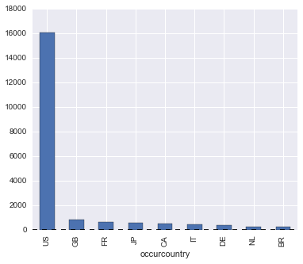

```python
fig = plt.subplots(1, 1, figsize = (6,5))
death['Sum'].plot(kind='bar')
```

Result: Many more information come from the US. For the other countries listed in the graph, the number of reports is similar.

The figure below shows the ratios for serious and the different serious outcomes for each country.

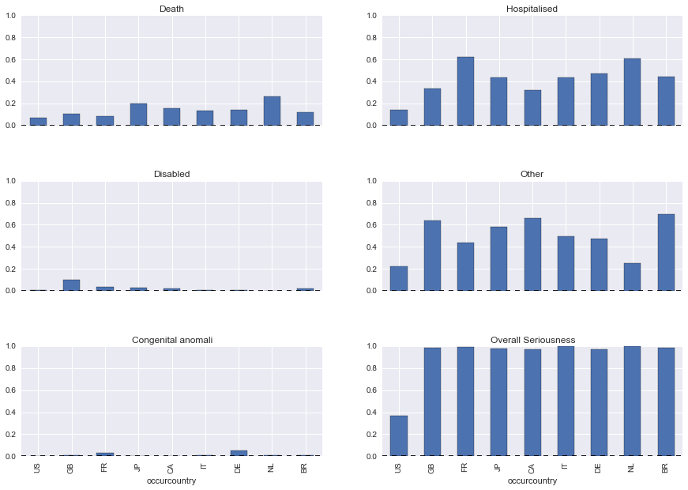

```python
#fig = plt.subplots(2, 2, figsize = (12,10))

fig, axes = plt.subplots(nrows=3, ncols=2, figsize = (15,10))
fig.subplots_adjust(hspace=.5)

plt.subplot(3, 2, 1)
death['RatioDeath'].plot(kind='bar',title = 'Death',ylim=[0,1])

plt.subplot(3, 2, 2)
hosp['RatioDeath'].plot(kind='bar',title = 'Hospitalised',ylim=[0,1])

plt.subplot(3, 2, 3)
disa['RatioDeath'].plot(kind='bar',title = 'Disabled',ylim=[0,1])

plt.subplot(3, 2, 4)
other['RatioDeath'].plot(kind='bar',title = 'Other',ylim=[0,1])

plt.subplot(3, 2, 5)
conge['RatioDeath'].plot(kind='bar',title = 'Congenital anomali',ylim=[0,1])

plt.subplot(3, 2, 6)
serious['RatioDeath'].plot(kind='bar',title = 'Overall Seriousness',ylim=[0,1])
```

Results: The overall seriousness is high, except of 'US' where reports are collected that do not end in serious effects. Other serious effects and hospitalisation are the main serious effects. The highest ration of deaths occur in NL and JP.

# Analyse patient.drug data

```python
dffdrugf.head()
```

|  |  | actiondrug | activesubstance | activesubstance.activesubstancename | drugadditional | drugadministrationroute | drugauthorizationnumb | drugbatchnumb | drugcharacterization | drugcumulativedosagenumb | drugcumulativedosageunit | ... | openfda.pharm_class_moa | openfda.pharm_class_pe | openfda.product_ndc | openfda.product_type | openfda.route | openfda.rxcui | openfda.spl_id | openfda.spl_set_id | openfda.substance_name | openfda.unii |
| --- | --- | --- | --- | --- | --- | --- | --- | --- | --- | --- | --- | --- | --- | --- | --- | --- | --- | --- | --- | --- | --- | --- |
| 0 | 0 | -1 | -1 | -1 | -1 | 042 | 021858 | H6200HO3 | 1 | -1 | -1 | ... | -1 | -1 | [0004-0191, 0004-0186] | [HUMAN PRESCRIPTION DRUG] | [ORAL, INTRAVENOUS] | [904934, 904954, 904952, 904932] | [4c65ed19-ef93-443d-ad40-0a1838fb0b2a, 2fbd353... | [5500be0f-8b29-450c-9857-755029965157, 841bf76... | [IBANDRONATE SODIUM] | [J12U072QL0] |
| 1 | 0 | -1 | -1 | -1 | 3 | -1 | 17463 | -1 | 1 | -1 | -1 | ... | [Cyclooxygenase Inhibitors [MoA]] | -1 | [63981-393, 49348-642, 0113-0660, 70000-0176, ... | [HUMAN OTC DRUG, HUMAN PRESCRIPTION DRUG] | [ORAL, INTRAVENOUS] | [544393, 153008, 1101919, 731533, 731531, 1978... | [369ce2a7-cdf3-414a-95d4-7f4ae6768427, 82fd7b5... | [369ce2a7-cdf3-414a-95d4-7f4ae6768427, 5f27dd3... | [DIPHENHYDRAMINE CITRATE, IBUPROFEN SODIUM, IB... | [RM1CE97Z4N, WK2XYI10QM, 4OD433S209] |
| 2 | 0 | 5 | -1 | -1 | -1 | -1 | 021446 | -1 | 1 | -1 | -1 | ... | -1 | -1 | [0071-1012, 0071-1013, 0071-1014, 0071-1015, 0... | [HUMAN PRESCRIPTION DRUG] | [ORAL] | [607038, 607033, 483448, 483450] | [97ad1752-d9b5-460f-b49c-c7551e70f07e, 0f9110b... | [ce1a4b9d-3127-4416-8bf2-fee5899fc0ba, 60185c8... | [PREGABALIN] | [55JG375S6M] |
| 3 | 0 | 5 | -1 | -1 | -1 | -1 | 050007 | -1 | 1 | -1 | -1 | ... | -1 | -1 | [59762-3690, 43547-324, 43547-325, 0591-6125, ... | [HUMAN PRESCRIPTION DRUG] | [ORAL, INTRAVENOUS] | [1543955, 1543953, 283535, 1650143, 1649988, 1... | [392533f7-e212-40e0-ad6f-b91c242f12e0, 1029d54... | [8a9e1d08-1665-46d2-bda6-aa11a3f18646, f5ee43b... | [DOXYCYCLINE HYCLATE] | [19XTS3T51U, N12000U13O, 8ZL07I20SB] |
|  | 1 | 5 | -1 | -1 | -1 | -1 | -1 | -1 | 1 | -1 | -1 | ... | -1 | -1 | [65862-734, 16714-481, 69467-1001, 65862-733, ... | [HUMAN PRESCRIPTION DRUG] | [ORAL] | [1148487, 845314, 835605, 835603, 845315, 8337... | [55677592-b577-4299-b7e3-7205a5d5aabb, 81d3295... | [55677592-b577-4299-b7e3-7205a5d5aabb, c88b97f... | [TRAMADOL HYDROCHLORIDE] | [9N7R477WCK] |

5 rows × 47 columns

The following tables show the diseases and their occurance, where '-1' indicate missing data. Result: Mostly the disease is unkown.

```python
dffdrugf['drugindication'].value_counts().head(10)
```

```
-1                                     26410
PRODUCT USED FOR UNKNOWN INDICATION    14806
RHEUMATOID ARTHRITIS                    2324
MULTIPLE SCLEROSIS                      1932
HYPERTENSION                            1109
PERITONEAL DIALYSIS                      830
PULMONARY ARTERIAL HYPERTENSION          729
PSORIASIS                                640
TYPE 2 DIABETES MELLITUS                 606
PLASMA CELL MYELOMA                      604
dtype: int64
```

The following tables show the active substance names and their occurance, where '-1' indicate missing data.

```python
dffdrugf['activesubstance.activesubstancename'].value_counts().head(15)
```

```
-1                                                              30197
AMBRISENTAN                                                      2076
ETANERCEPT                                                       1257
ASPIRIN                                                           627
ATORVASTATIN CALCIUM                                              584
CALCIUM CHLORIDE\DEXTROSE\MAGNESIUM CHLORIDE\SODIUM CHLORIDE\SODIUM LACTATE      547
LENALIDOMIDE                                                      537
METFORMIN HYDROCHLORIDE                                           421
RIVAROXABAN                                                       410
ADALIMUMAB                                                        390
PREGABALIN                                                        387
ACETAMINOPHEN                                                     384
PREDNISONE                                                        382
FUROSEMIDE                                                        364
TREPROSTINIL                                                      343
dtype: int64
```

```python
dffdrugf['drugadditional'].value_counts()
```

```
-1    69913
3      4185
1      1509
2       355
dtype: int64
```

The following table shows the dosage form and how often it occurs. Result: The most common form of dosage form are tablets.

```python
dffdrugf['drugdosageform'].value_counts().head(10)
```

```
-1                                              43012
TABLET                                           9398
UNKNOWN                                          2435
FILM-COATED TABLET                               2162
CAPSULE                                          1675
SOLUTION FOR INJECTION                           1408
INJECTION                                        1346
UNSPECIFIED                                      1253
SOLUTION FOR INJECTION IN PRE-FILLED SYRINGE     1087
SOLUTION FOR PERITONEAL DIALYSIS                  982
dtype: int64
```

All variables in the table can be analysed in the same way. I don't show them here to shorten the report.

The following table shows the generic name(s) of the drugs.

```python
dffdrug['openfda.generic_name'].unstack().head(10)
```

|  | 0 | 1 | 2 | 3 | 4 | 5 | 6 | 7 | 8 | 9 | ... | 67 | 68 | 69 | 70 | 71 | 72 | 73 | 74 | 75 | 76 |
| --- | --- | --- | --- | --- | --- | --- | --- | --- | --- | --- | --- | --- | --- | --- | --- | --- | --- | --- | --- | --- | --- |
| 0 | [IBANDRONATE SODIUM] | NaN | NaN | NaN | NaN | NaN | NaN | NaN | NaN | NaN | ... | NaN | NaN | NaN | NaN | NaN | NaN | NaN | NaN | NaN | NaN |
| 1 | [IBUPFROFEN, IBUPROFEN 200MG, IBUPROFEN 200 MG... | NaN | NaN | NaN | NaN | NaN | NaN | NaN | NaN | NaN | ... | NaN | NaN | NaN | NaN | NaN | NaN | NaN | NaN | NaN | NaN |
| 2 | [PREGABALIN] | NaN | NaN | NaN | NaN | NaN | NaN | NaN | NaN | NaN | ... | NaN | NaN | NaN | NaN | NaN | NaN | NaN | NaN | NaN | NaN |
| 3 | [DOXYCYCLINE, DOXYCYCLINE HYCLATE] | [TRAMADOL HYDROCHLORIDE, TRAMADOL HYDROCHLORID... | [OXYCODONE HYDROCHLORIDE] | [PENTAZOCINE LACTATE] | [CODEINE] | [IODINE ALCOHOLIC, POVIDONE-IODINE, IODINE] | [ASPIRIN 325 MG, REGULAR STRENGTH ASPIRIN, ASP... | [HYDROCODONE BITARTRATE AND ACETAMINOPHEN] | [BUTALBITAL, ASPIRIN, AND CAFFEINE] | NaN | ... | NaN | NaN | NaN | NaN | NaN | NaN | NaN | NaN | NaN | NaN |
| 4 | [ATORVASTATIN CALCIUM] | [LISINOPRIL] | [LOSARTAN POTASSIUM] | [METOPROLOL, METOPROLOL TARTRATE] | [MINOCYCLINE HYDROCHLORIDE, MINOCYCLINE] | [SULFAMETHOXAZOLE AND TRIMETHOPRIM] | NaN | NaN | NaN | NaN | ... | NaN | NaN | NaN | NaN | NaN | NaN | NaN | NaN | NaN | NaN |
| 5 | [AMBRISENTAN] | [TREPROSTINIL] | NaN | NaN | NaN | NaN | NaN | NaN | NaN | NaN | ... | NaN | NaN | NaN | NaN | NaN | NaN | NaN | NaN | NaN | NaN |
| 6 | [AMBRISENTAN] | [0XYGEN, OXYGEN COMPRESSED, OXYGEN] | [AMBRISENTAN] | NaN | NaN | NaN | NaN | NaN | NaN | NaN | ... | NaN | NaN | NaN | NaN | NaN | NaN | NaN | NaN | NaN | NaN |
| 7 | [AMBRISENTAN] | [AMBRISENTAN] | NaN | NaN | NaN | NaN | NaN | NaN | NaN | NaN | ... | NaN | NaN | NaN | NaN | NaN | NaN | NaN | NaN | NaN | NaN |
| 8 | [AMBRISENTAN] | [AMBRISENTAN] | NaN | NaN | NaN | NaN | NaN | NaN | NaN | NaN | ... | NaN | NaN | NaN | NaN | NaN | NaN | NaN | NaN | NaN | NaN |
| 9 | [PREGABALIN] | [METOPROLOL, METOPROLOL TARTRATE] | [ALPRAZOLAM] | [AMBRISENTAN] | [TADALAFIL] | [SIMVASTATIN] | [FLUTICASONE PROPIONATE AND SALMETEROL XINAFOATE] | [ASPIRIN 325 MG, REGULAR STRENGTH ASPIRIN, ASP... | [ESOMEPRAZOLE MAGNESIUM, ESOMEPRAZOLE SODIUM] | [TRIAMTERENE] | ... | NaN | NaN | NaN | NaN | NaN | NaN | NaN | NaN | NaN | NaN |

10 rows × 77 columns

# Analysing patient.drug per country

### Function to easily derive information per country

```python
def daten_country(param): # the parameter is the country here
    dfdrugUS = {}
    kl = 0

    for i in range(laenge):
        if dfdatenf['occurcountry'][i] == param:
            dfdf = json_normalize(dfdatenf['patient.drug'][i])
            dfdrugUS[kl] = dfdf
            kl = kl+1

    print('num',kl)
    dfdrugUSs = pd.concat(dfdrugUS)
    dfdrugUSs = dfdrugUSs.fillna(-1)
    return dfdrugUSs
```

## Analyse the Actions per country

I prepare a little function to easily derive the action per country. Any other parameter can be included here for deriving its values per country. The numbers in the tables below mean: Value is one of the following

```
1 = Drug withdrawn

2 = Dose reduced

3 = Dose increased

4 = Dose not changed

5 = Unknown

6 = Not applicable

-1 = Missing data
```

```python
def prepare_data(countryparam):
    dfUS = daten_country(countryparam)
    dfUSaction = dfUS['actiondrug'].value_counts()
    dfactionss = []
    summe1 = sum(dfUSaction)
    print(summe1)
    dfactions1 = pd.DataFrame(dfUSaction).T
    dfactions1['sum'] = summe1
    dfactions1.index = [countryparam]
    return dfactions1
```

```python
dfactionUS = prepare_data('US')
dfactionUS
```

```
('num', 16118)
45498
```

|  | -1 | 5 | 4 | 1 | 6 | 2 | 3 | sum |
| --- | --- | --- | --- | --- | --- | --- | --- | --- |
| US | 21550 | 9683 | 7401 | 4877 | 1156 | 514 | 317 | 45498 |

```python
dfactionGB = prepare_data('GB')
dfactionGB
```

```
('num', 873)
4070
```

|  | -1 | 5 | 1 | 4 | 6 | 2 | 3 | sum |
| --- | --- | --- | --- | --- | --- | --- | --- | --- |
| GB | 1989 | 1020 | 576 | 292 | 139 | 32 | 22 | 4070 |

```python
dfactionJP = prepare_data('JP')
dfactionJP
```

```
('num', 589)
3783
```

|  | -1 | 1 | 5 | 4 | 6 | 2 | 3 | sum |
| --- | --- | --- | --- | --- | --- | --- | --- | --- |
| JP | 1881 | 681 | 570 | 498 | 70 | 69 | 14 | 3783 |

```python
dfactionFR = prepare_data('FR')
dfactionFR
```

```
('num', 642)
3704
```

|  | -1 | 5 | 1 | 4 | 6 | 2 | 3 | sum |
| --- | --- | --- | --- | --- | --- | --- | --- | --- |
| FR | 1451 | 930 | 853 | 322 | 98 | 39 | 11 | 3704 |

```python
dfactionCA = prepare_data('CA')
dfactionCA
```

```
('num', 538)
2281
```

|  | -1 | 5 | 4 | 1 | 6 | 3 | 2 | sum |
| --- | --- | --- | --- | --- | --- | --- | --- | --- |
| CA | 916 | 754 | 256 | 245 | 77 | 17 | 16 | 2281 |

```python
dfactionNL = prepare_data('NL')
dfactionNL
```

```
('num', 268)
506
```

|  | 5 | -1 | 1 | 4 | 6 | 2 | sum |
| --- | --- | --- | --- | --- | --- | --- | --- |
| NL | 232 | 186 | 47 | 20 | 19 | 2 | 506 |

```python
dfactionDE = prepare_data('DE')
dfactionDE
```

```
('num', 403)
1545
```

|  | -1 | 1 | 5 | 4 | 6 | 3 | 2 | sum |
| --- | --- | --- | --- | --- | --- | --- | --- | --- |
| DE | 635 | 293 | 264 | 229 | 94 | 16 | 14 | 1545 |

Combine the above derived data in one dataframe.

```python
FramesAct = [dfactionUS,dfactionGB,dfactionJP,dfactionFR,dfactionCA,dfactionNL,dfactionDE]
dfActionsCountries = pd.concat(FramesAct)
dfActionsCountries
```

|  | -1 | 1 | 2 | 3 | 4 | 5 | 6 | sum |
| --- | --- | --- | --- | --- | --- | --- | --- | --- |
| US | 21550 | 4877 | 514 | 317 | 7401 | 9683 | 1156 | 45498 |
| GB | 1989 | 576 | 32 | 22 | 292 | 1020 | 139 | 4070 |
| JP | 1881 | 681 | 69 | 14 | 498 | 570 | 70 | 3783 |
| FR | 1451 | 853 | 39 | 11 | 322 | 930 | 98 | 3704 |
| CA | 916 | 245 | 16 | 17 | 256 | 754 | 77 | 2281 |
| NL | 186 | 47 | 2 | NaN | 20 | 232 | 19 | 506 |
| DE | 635 | 293 | 14 | 16 | 229 | 264 | 94 | 1545 |

Replace the numbers by names and derive the ratios per country and action.

1 = Drug withdrawn, 2 = Dose reduced, 3 = Dose increased, 4 = Dose not changed, 5 = Unknown, 6 = Not applicable

```python
dfActionsCountries['Withdraw'] = dfActionsCountries['1']/dfActionsCountries['sum']
dfActionsCountries['Reduce'] = dfActionsCountries['2']/dfActionsCountries['sum']
dfActionsCountries['Increase'] = dfActionsCountries['3']/dfActionsCountries['sum']
dfActionsCountries['NotChanged'] = dfActionsCountries['4']/dfActionsCountries['sum']
dfActionsCountries['NotApplicable'] = dfActionsCountries['6']/dfActionsCountries['sum']
dfActionsCountries
```

|  | -1 | 1 | 2 | 3 | 4 | 5 | 6 | sum | Withdraw | Reduce | Increase | NotChanged | NotApplicable |
| --- | --- | --- | --- | --- | --- | --- | --- | --- | --- | --- | --- | --- | --- |
| US | 21550 | 4877 | 514 | 317 | 7401 | 9683 | 1156 | 45498 | 0.107192 | 0.011297 | 0.006967 | 0.162666 | 0.025408 |
| GB | 1989 | 576 | 32 | 22 | 292 | 1020 | 139 | 4070 | 0.141523 | 0.007862 | 0.005405 | 0.071744 | 0.034152 |
| JP | 1881 | 681 | 69 | 14 | 498 | 570 | 70 | 3783 | 0.180016 | 0.018239 | 0.003701 | 0.131642 | 0.018504 |
| FR | 1451 | 853 | 39 | 11 | 322 | 930 | 98 | 3704 | 0.230292 | 0.010529 | 0.002970 | 0.086933 | 0.026458 |
| CA | 916 | 245 | 16 | 17 | 256 | 754 | 77 | 2281 | 0.107409 | 0.007014 | 0.007453 | 0.112231 | 0.033757 |
| NL | 186 | 47 | 2 | NaN | 20 | 232 | 19 | 506 | 0.092885 | 0.003953 | NaN | 0.039526 | 0.037549 |
| DE | 635 | 293 | 14 | 16 | 229 | 264 | 94 | 1545 | 0.189644 | 0.009061 | 0.010356 | 0.148220 | 0.060841 |

The plot below shows the ratios of actions per country .

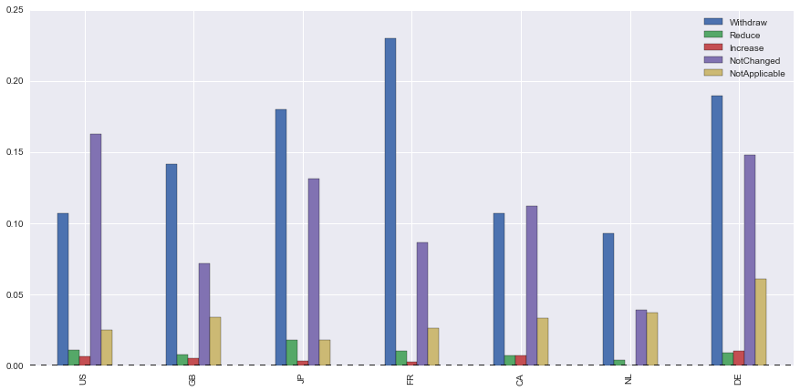

```python
dfPlotAction = dfActionsCountries[['Withdraw','Reduce','Increase','NotChanged','NotApplicable']].copy()

dfPlotAction.plot(kind = 'bar', figsize = (15,7))
```

Results: In the US and CA the number of withdrawns is smaller than the number of NotChanged. In the other countries the drug is rahter withdrawn. Drugs are very rarely reduced or increased.

# Merging dfdaten and dfdrug with specific conditions for analysis

I combined the general patient information and the ones in the patient.drug column and chose the following columns for analysis from patient.drug table. The information (with multiindex) are summarised in the dataframe dfzusa.

```python
dfzusa = dffdrug[['drugstartdate','drugenddate','medicinalproduct','actiondrug','drugtreatmentduration',
       'drugtreatmentdurationunit','drugstructuredosagenumb',
       'drugstructuredosageunit','drugcharacterization','drugindication']]
dfzusa.index.names = ['index1', 'index2']
dfzusa['Index'] = dfzusa.index.get_level_values('index1')

dfzusa.head()
```

| index1 | index2 | drugstartdate | drugenddate | medicinalproduct | actiondrug | drugtreatmentduration | drugtreatmentdurationunit | drugstructuredosagenumb | drugstructuredosageunit | drugcharacterization | drugindication | Index |
| --- | --- | --- | --- | --- | --- | --- | --- | --- | --- | --- | --- | --- |
| 0 | 0 | 20130913 | NaN | BONIVA | NaN | NaN | NaN | 3 | 003 | 1 | OSTEOPOROSIS | 0 |
| 1 | 0 | NaN | NaN | IBUPROFEN | NaN | NaN | NaN | NaN | NaN | 1 | PRODUCT USED FOR UNKNOWN INDICATION | 1 |
| 2 | 0 | NaN | NaN | LYRICA | 5 | NaN | NaN | NaN | NaN | 1 | NaN | 2 |
| 3 | 0 | NaN | NaN | DOXYCYCLINE HYCLATE | 5 | NaN | NaN | NaN | NaN | 1 | NaN | 3 |
|  | 1 | NaN | NaN | TRAMADOL HYDROCHLORIDE | 5 | NaN | NaN | NaN | NaN | 1 | NaN | 3 |

## List the top substances reported in the different countries

```python
dfUS = daten_country('US')
```

```
('num', 16118)
```

[output not shown]

```python
dfGB = daten_country('GB')
dfJP = daten_country('JP')
dfFR = daten_country('FR')
dfCA = daten_country('CA')
dfNL = daten_country('NL')
dfDE = daten_country('DE')
```

```
('num', 873)
('num', 589)
('num', 642)
('num', 538)
('num', 268)
('num', 403)
```

The following tables show the active substance names for the different country in the order: US, GB, JP, FR, CA, NL, DE. -1 indicates missing data.

```python
dfUS['activesubstance.activesubstancename'].value_counts().head(10)
```

```
-1                                                              16895
AMBRISENTAN                                                      2074
ETANERCEPT                                                       1108
ATORVASTATIN CALCIUM                                              543
LENALIDOMIDE                                                      475
CALCIUM CHLORIDE\DEXTROSE\MAGNESIUM CHLORIDE\SODIUM CHLORIDE\SODIUM LACTATE      432
ASPIRIN                                                           395
TREPROSTINIL                                                      339
PREGABALIN                                                        315
TIOTROPIUM BROMIDE MONOHYDRATE                                    293
dtype: int64
```

```python
dfGB['activesubstance.activesubstancename'].value_counts().head(10)
```

```
-1                     1579
ASPIRIN                  59
CLOZAPINE                58
ACETAMINOPHEN            58
ATORVASTATIN             48
OMEPRAZOLE               45
SIMVASTATIN              42
DARBEPOETIN ALFA         42
RAMIPRIL                 40
AMLODIPINE BESYLATE      40
dtype: int64
```

```python
dfJP['activesubstance.activesubstancename'].value_counts().head(10)
```

```
-1                       1380
CLOZAPINE                  83
PREDNISOLONE               64
SELUMETINIB                38
TACROLIMUS                 36
LANSOPRAZOLE               33
NIVOLUMAB                  31
INSULIN LISPRO             31
PEGINTERFERON ALFA-2B      29
ACETAMINOPHEN              26
dtype: int64
```

```python
dfFR['activesubstance.activesubstancename'].value_counts().head(10)
```

```
-1                973
ACETAMINOPHEN      58
ASPIRIN LYSINE     49
PREDNISONE         47
FUROSEMIDE         47
ZIDOVUDINE         40
STAVUDINE          38
ESOMEPRAZOLE       35
RITUXIMAB          34
LEVOTHYROXINE      31
dtype: int64
```

```python
dfCA['activesubstance.activesubstancename'].value_counts().head(10)
```

```
-1                    695
OMALIZUMAB            106
INFLIXIMAB             68
PREDNISONE             44
METHOTREXATE           40
ADALIMUMAB             40
DENOSUMAB              29
ETANERCEPT             27
OCTREOTIDE ACETATE     24
VEDOLIZUMAB            21
dtype: int64
```

```python
dfNL['activesubstance.activesubstancename'].value_counts().head(10)
```

```
-1                                                        275
DARBEPOETIN ALFA                                           26
DENOSUMAB                                                  25
OCTREOTIDE ACETATE                                         14
LEUPROLIDE ACETATE                                         14
PEGFILGRASTIM                                               7
OMALIZUMAB                                                  5
ACENOCOUMAROL                                               4
HUMAN IMMUNOGLOBULIN G\HYALURONIDASE RECOMBINANT HUMAN      4
LISINOPRIL                                                  4
dtype: int64
```

```python
dfDE['activesubstance.activesubstancename'].value_counts().head(10)
```

```
-1                     745
PANTOPRAZOLE SODIUM     22
ADALIMUMAB              17
ASPIRIN                 16
PREDNISOLONE            16
DIMETHYL FUMARATE       16
SIMVASTATIN             15
ALLOPURINOL             13
APIXABAN                11
HYDROCHLOROTHIAZIDE     11
dtype: int64
```

## List the top medications reported in the different countries

```python
dfUS['medicinalproduct'].value_counts().head(10)
```

```
ENBREL                                                          2517
LETAIRIS                                                        2093
LIPITOR                                                         1100
TECFIDERA                                                        779
REVLIMID                                                         605
JAKAFI                                                           531
LYRICA                                                           507
AVONEX                                                           450
TYSABRI                                                          449
DIANEAL LOW CALCIUM PERITONEAL DIALYSIS SOLUTION WITH DEXTROSE     419
dtype: int64
```

```python
dfGB['medicinalproduct'].value_counts().head(10)
```

```
PARACETAMOL     94
ATORVASTATIN    75
AMLODIPINE      65
CLOZARIL        58
ASPIRIN.        52
OMEPRAZOLE.     43
ARANESP         42
METFORMIN       41
BISOPROLOL      40
CITALOPRAM      40
dtype: int64
```

```python
dfJP['medicinalproduct'].value_counts().head(10)
```

```
CLOZARIL                82
PREDONINE               59
PREDNISOLONE            51
PREDNISOLONE.           49
CLOZARIL (CLOZAPINE)    42
AZD6244                 38
PROGRAF                 35
TACROLIMUS.             33
LASIX                   32
BAYASPIRIN              31
dtype: int64
```

```python
dfFR['medicinalproduct'].value_counts().head(10)
```

```
KARDEGIC        66
PARACETAMOL     47
CORTANCYL       44
INEXIUM         39
RETROVIR        38
LEVOTHYROX      36
ZERIT           36
LASILIX         33
XARELTO         31
METHOTREXATE    30
dtype: int64
```

```python
dfCA['medicinalproduct'].value_counts().head(10)
```

```
XOLAIR           106
REMICADE          89
HUMIRA            59
PREDNISONE.       42
ENBREL            40
ACLASTA           29
PROLIA            25
METHOTREXATE      24
STELARA           22
METHOTREXATE.     21
dtype: int64
```

```python
dfNL['medicinalproduct'].value_counts().head(10)
```

```
NEULASTA                 87
ARANESP                  54
XGEVA                    52
ACLASTA                  14
SANDOSTATIN LAR DEPOT    14
ZOMETA                   10
LUCRIN DEPOT              9
NPLATE                    7
SPIRONOLACTON             5
XOLAIR                    5
dtype: int64
```

```python
dfDE['medicinalproduct'].value_counts().head(10)
```

```
HUMIRA           47
TECFIDERA        17
PANTOZOL         16
XARELTO          15
PRIVIGEN         14
ALLOPURINOL.     14
DOXORUBICIN      13
PREDNISOLONE.    13
SIMVASTATIN.     12
METFORMIN        12
dtype: int64
```

### Pivot data to get a list of what medicine caused what action independent of country

The following table shows the top 10 (odered by medicinal product). Specific medicinal products can be chosen and analysed. With the following pivot calculations, information other than 'actiondrug' can be analysed.

The values mean 1 = Drug withdrawn, 2 = Dose reduced, 3 = Dose increased, 4 = Dose not changed, 5 = Unknown, 6 = Not applicable, -1 = Missing data

```python
dfUSmed = dfUS.pivot_table(index='medicinalproduct', columns='actiondrug', aggfunc='count', fill_value=0)
dfUSmed['drugadditional'].head(10)
# aggfunc=len, fill_value=0 count frequency
```

| actiondrug medicinalproduct | -1 | 1 | 2 | 3 | 4 | 5 | 6 |
| --- | --- | --- | --- | --- | --- | --- | --- |
| 2 OTHER UNKNOWN MEDICATIONS | 0 | 0 | 0 | 0 | 0 | 2 | 0 |
| 4 WAY UNKNOWN | 0 | 0 | 0 | 0 | 1 | 0 | 0 |
| 4-HYDROXY-N-METHYL-N-ETHYLTRYPTAMINE | 1 | 0 | 0 | 0 | 0 | 0 | 0 |
| 4-METHOXYPHENCYCLIDINE | 1 | 0 | 0 | 0 | 0 | 0 | 0 |
| 433 (CARBAMAZEPINE) | 0 | 0 | 0 | 0 | 1 | 0 | 0 |
| 476 (MESALAZINE/MESALAMINE) | 0 | 0 | 0 | 0 | 0 | 1 | 0 |
| 5 FU | 1 | 0 | 0 | 0 | 0 | 0 | 0 |
| 5-ASA | 5 | 0 | 0 | 0 | 0 | 0 | 0 |
| 5-AZACYTIDINE | 0 | 0 | 0 | 0 | 0 | 1 | 0 |
| 5-FLUOROURACIL | 0 | 2 | 0 | 0 | 0 | 0 | 0 |

### Top 10 reportet medical products

```python
dfzusa['medicinalproduct'].value_counts().head(10)
```

```
ENBREL       2712
LETAIRIS     2093
LIPITOR      1137
TECFIDERA     814
REVLIMID      674
LYRICA        591
HUMIRA        546
JAKAFI        540
XARELTO       524
AVONEX        473
dtype: int64
```

In the following the information of one of these drugs "Jakafi" will be analysed in more detail. By replacing the name in the first code, other drugs can be easily analysed.

### Choose data for analysis from patient table to combine with patient.drug information

```python
dfcountry = dfdatenf[['occurcountry','companynumb','seriousnesscongenitalanomali', 'seriousnessdeath',
       'seriousnessdisabling', 'seriousnesshospitalization','seriousnesslifethreatening', 'seriousnessother',
        'serious','receiptdate']].copy()
dfcountry['Index'] = dfcountry.index
dfcountry.head()
```

|  | occurcountry | companynumb | seriousnesscongenitalanomali | seriousnessdeath | seriousnessdisabling | seriousnesshospitalization | seriousnesslifethreatening | seriousnessother | serious | receiptdate | Index |
| --- | --- | --- | --- | --- | --- | --- | --- | --- | --- | --- | --- |
| 0 | -1 | 1289378 | -1 | -1 | 1 | -1 | -1 | -1 | 1 | 20140306 | 0 |
| 1 | -1 | US-JNJFOC-20130719067 | -1 | -1 | -1 | -1 | -1 | 1 | 1 | 20140228 | 1 |
| 2 | US | US-PFIZER INC-2014068976 | -1 | -1 | -1 | -1 | -1 | -1 | 2 | 20140312 | 2 |
| 3 | US | US-PFIZER INC-2014063856 | -1 | -1 | -1 | -1 | -1 | -1 | 2 | 20140424 | 3 |
| 4 | US | US-PFIZER INC-2014069067 | -1 | -1 | -1 | -1 | -1 | -1 | 2 | 20140312 | 4 |

## The following function combines data and patient.drug table, using the information of medicinalproduct from patient.drug table.

In the following function the parameter 'param' indicates a word that is contained in medicinalproduct.

In the following the results are shown for the medication 'JAKAFI'.

```python
def analysis_drug(paramdrug):
    #select rows where columns contain certain value
    dfaspirin = dfzusa[dfzusa['medicinalproduct'].str.contains(paramdrug)]
    dfaspirin = dfaspirin.reset_index(level=1, drop=True)

    dftry = pd.merge(dfaspirin,dfcountry,left_index=True,right_index=True, how='left')
    dftryna = dftry.fillna(-1)

    print(paramdrug)
    print('--------Country--------')
    print(dftryna['occurcountry'].value_counts().head())
    print('--------Dosage--------')
    print(dftryna['drugstructuredosagenumb'].value_counts().head())
    print(dftryna['drugstructuredosageunit'].value_counts().head())
    print('--------Duration--------')
    print(dftryna['drugtreatmentduration'].value_counts().head())
    print('--------Death--------')
    print(dftryna['seriousnessdeath'].value_counts().head())
    print('--------Conten--------')
    print(dftryna['seriousnesscongenitalanomali'].value_counts().head())
    print('--------Hospit--------')
    print(dftryna['seriousnesshospitalization'].value_counts().head())
    print('--------lifethre--------')
    print(dftryna['seriousnesslifethreatening'].value_counts().head())
    print('--------Other--------')
    print(dftryna['seriousnessother'].value_counts().head())
    print('--------Serious--------')
    print(dftryna['serious'].value_counts().head())
    print('--------combi--------')
    print(dftryna['drugcharacterization'].value_counts().head())
    print('--------disea--------')
    print(dftryna['drugindication'].value_counts().head())
    return dftryna
```

### Show the summary information and save output table in a dataframe

The function gives directly various information in connection with the medication JAKAFI.

```python
dfjakafi = analysis_drug('JAKAFI')
```

```
JAKAFI
--------Country--------
US    531
DE      4
SA      3
NO      1
FR      1
dtype: int64
--------Dosage--------
10    137
20    123
5     100
15     98
-1     57
dtype: int64
003    483
-1      57
dtype: int64
--------Duration--------
-1    540
dtype: int64
--------Death--------
-1    519
1      21
dtype: int64
--------Conten--------
-1    540
dtype: int64
--------Hospit--------
-1    505
1      35
dtype: int64
--------lifethre--------
-1    540
dtype: int64
--------Other--------
-1    448
1      92
dtype: int64
--------Serious--------
2    405
1    135
dtype: int64
--------combi--------
1    540
dtype: int64
--------disea--------
MYELOFIBROSIS                  270
-1                             208
POLYCYTHAEMIA VERA              14
MYELODYSPLASTIC SYNDROME        12
MYELOPROLIFERATIVE DISORDER      8
dtype: int64
```

Unknown values are filled with -1.

Serious: 1=yes, 2=no

The output dataframe gives the overall information about the drug.

```python
dfjakafi.head()
```

|  | drugstartdate | drugenddate | medicinalproduct | actiondrug | drugtreatmentduration | drugtreatmentdurationunit | drugstructuredosagenumb | drugstructuredosageunit | drugcharacterization | drugindication | ... | companynumb | seriousnesscongenitalanomali | seriousnessdeath | seriousnessdisabling | seriousnesshospitalization | seriousnesslifethreatening | seriousnessother | serious | receiptdate | Index_y |
| --- | --- | --- | --- | --- | --- | --- | --- | --- | --- | --- | --- | --- | --- | --- | --- | --- | --- | --- | --- | --- | --- |
| 206 | 20131212 | -1 | JAKAFI | 5 | -1 | -1 | 5 | 003 | 1 | MYELOFIBROSIS | ... | US-INCYTE CORPORATION-2014IN000031 | -1 | -1 | -1 | -1 | -1 | -1 | 2 | 20140312 | 206 |
| 216 | 201310 | -1 | JAKAFI | 5 | -1 | -1 | -1 | -1 | 1 | MYELOFIBROSIS | ... | US-INCYTE CORPORATION-2014IN000064 | -1 | -1 | -1 | -1 | -1 | 1 | 1 | 20140312 | 216 |
| 219 | 2012 | -1 | JAKAFI | -1 | -1 | -1 | 15 | 003 | 1 | MYELOFIBROSIS | ... | US-INCYTE CORPORATION-2013IN002858 | -1 | -1 | -1 | -1 | -1 | -1 | 2 | 20140312 | 219 |
| 220 | 201309 | -1 | JAKAFI | -1 | -1 | -1 | 10 | 003 | 1 | MYELOFIBROSIS | ... | US-INCYTE CORPORATION-2014IN000019 | -1 | -1 | -1 | -1 | -1 | -1 | 2 | 20140312 | 220 |
| 224 | 20131122 | -1 | JAKAFI | 1 | -1 | -1 | 15 | 003 | 1 | MYELOFIBROSIS | ... | US-INCYTE CORPORATION-2013IN002944 | -1 | -1 | -1 | -1 | -1 | -1 | 2 | 20140611 | 224 |

5 rows × 22 columns

In the following the results from the above table are analysed in more detail.

### For what diseases is this drug used in the different countries and how many reports are there for each case?

-1 indicates missing data

```python
dfdisjak = pd.pivot_table(dfjakafi,index=["drugindication"],values = ["actiondrug"],columns='occurcountry', aggfunc='count')
dfdisjak['actiondrug']
```

| occurcountry drugindication | DE | FR | NO | SA | US |
| --- | --- | --- | --- | --- | --- |
| -1 | 3 | NaN | NaN | 2 | 203 |
| ESSENTIAL THROMBOCYTHAEMIA | NaN | NaN | NaN | NaN | 4 |
| FAMILIAL POLYCYTHAEMIA | NaN | NaN | NaN | NaN | 2 |
| HEPATOSPLENOMEGALY | NaN | NaN | NaN | NaN | 1 |
| ILL-DEFINED DISORDER | NaN | NaN | NaN | NaN | 2 |
| JANUS KINASE 2 MUTATION | NaN | NaN | NaN | NaN | 2 |
| LEUKAEMIA | NaN | NaN | NaN | NaN | 2 |
| LYMPHOCYTIC LEUKAEMIA | NaN | NaN | NaN | NaN | 2 |
| MALIGNANT MELANOMA | NaN | NaN | NaN | NaN | 2 |
| MYELODYSPLASTIC SYNDROME | NaN | NaN | NaN | NaN | 12 |
| MYELOFIBROSIS | 1 | 1 | NaN | NaN | 268 |
| MYELOPROLIFERATIVE DISORDER | NaN | NaN | NaN | NaN | 8 |
| NEOPLASM | NaN | NaN | NaN | NaN | 2 |
| POLYCYTHAEMIA | NaN | NaN | NaN | NaN | 2 |
| POLYCYTHAEMIA VERA | NaN | NaN | NaN | NaN | 14 |
| PRIMARY MYELOFIBROSIS | NaN | NaN | NaN | 1 | NaN |
| PRODUCT USED FOR UNKNOWN INDICATION | NaN | NaN | 1 | NaN | NaN |
| PULMONARY ARTERIAL HYPERTENSION | NaN | NaN | NaN | NaN | 2 |
| SPLENOMEGALY | NaN | NaN | NaN | NaN | 3 |

Results: The drug was mainly used and/or reported in the US.

### How many people who took this drug died in the different countries.

-1 indicates missing data, while 1 stands for death.

```python
dfConDeath = pd.pivot_table(dfjakafi,index=["occurcountry"],values = ["actiondrug"],columns='seriousnessdeath', aggfunc='count')
dfaus = dfConDeath['actiondrug']
dfaus.sort('1',ascending = False).head(8)
```

| seriousnessdeath occurcountry | -1 | 1 |
| --- | --- | --- |
| US | 513 | 18 |
| SA | NaN | 3 |
| DE | 4 | NaN |
| FR | 1 | NaN |
| NO | 1 | NaN |

Result: In the US where the drug was mainly reported, only 18 serious events are listed.

### How many people had a certain disease and died who took this drug?

-1 indicates that the disease is not known.

```python
dfConDeath = pd.pivot_table(dfjakafi,index=["drugindication"],values = ["actiondrug"],columns='seriousnessdeath', aggfunc='count')
dfaus = dfConDeath['actiondrug']
dfaus.sort('1',ascending = False).head(10)
```

| seriousnessdeath drugindication | -1 | 1 |
| --- | --- | --- |
| -1 | 193 | 15 |
| MYELOFIBROSIS | 265 | 5 |
| PRIMARY MYELOFIBROSIS | NaN | 1 |
| ESSENTIAL THROMBOCYTHAEMIA | 4 | NaN |
| FAMILIAL POLYCYTHAEMIA | 2 | NaN |
| HEPATOSPLENOMEGALY | 1 | NaN |
| ILL-DEFINED DISORDER | 2 | NaN |
| JANUS KINASE 2 MUTATION | 2 | NaN |
| LEUKAEMIA | 2 | NaN |
| LYMPHOCYTIC LEUKAEMIA | 2 | NaN |

Result: The drug was mainly used for Myelofibrosis, but only for 5 patients with this disease it had a serious effect.

### What top 10 medication are taken in combination with the analysed one?

```python
dftogether = pd.merge(dfjakafi, dfzusa, left_on = 'Index_y', right_on = 'Index', how='left')

g1 = dftogether.groupby( [ "medicinalproduct_x", "medicinalproduct_y"] ).count()
gg1 = pd.DataFrame(g1['drugstartdate_x'])
gg1.sort('drugstartdate_x',ascending = False).head(11)
```

| medicinalproduct_x | medicinalproduct_y | drugstartdate_x |
| --- | --- | --- |
| JAKAFI | JAKAFI | 1028 |
|  | ASPIRIN | 72 |
|  | ALLOPURINOL | 56 |
|  | OMEPRAZOLE | 41 |
|  | METOPROLOL | 41 |
|  | LEVOTHYROXINE | 34 |
|  | CALCIUM | 32 |
|  | ZYRTEC | 30 |
|  | MULTIVITAMINS | 28 |
|  | LISINOPRIL | 24 |
|  | FISH OIL | 24 |

Result: the most common drugs taken in combination with Jakafi are Aspirin and Allopurinol.

## The following function summarizes results for the different diseases and shows the top 5 outputs per parameter and returns a table for further analysis.

The parameters 'paramdis' set name of the disease or part of it and 'show' indicates if results should be displayed (1) or not (0).

```python
def analysis_disease(paramdis,show):
    #select rows where columns contain certain value
    dfdis     = dfzusa.dropna(subset = ['drugindication'])
    dfaspirin = dfdis[dfdis['drugindication'].str.contains(paramdis)]
    dfaspirin = dfaspirin.reset_index(level=1, drop=True)

    dftry = pd.merge(dfaspirin,dfcountry,left_index=True,right_index=True, how='left')
    dftryna = dftry.fillna(-1)

    if show == 1:
        print(paramdis)
        print('--------Country--------')
        print(dftryna['occurcountry'].value_counts().head())
        print('--------Dosage--------')
        print(dftryna['drugstructuredosagenumb'].value_counts().head())
        print('--------Duration--------')
        print(dftryna['drugtreatmentduration'].value_counts().head())
        print('--------Death--------')
        print(dftryna['seriousnessdeath'].value_counts().head())
        print('--------Conten--------')
        print(dftryna['seriousnesscongenitalanomali'].value_counts().head())
        print('--------Hospit--------')
        print(dftryna['seriousnesshospitalization'].value_counts().head())
        print('--------lifethre--------')
        print(dftryna['seriousnesslifethreatening'].value_counts().head())
        print('--------Other--------')
        print(dftryna['seriousnessother'].value_counts().head())
        print('--------Serious--------')
        print(dftryna['serious'].value_counts().head())
        print('--------combi--------')
        print(dftryna['drugcharacterization'].value_counts().head())
        print('--------medic--------')
        print(dftryna['medicinalproduct'].value_counts().head())

    return dftryna
```

### The first disease analysed is 'MYELOFIBROSIS'

```python
dfout = analysis_disease('MYELOFIBROSIS',1)
```

```
MYELOFIBROSIS
--------Country--------
US    276
JP      5
DE      3
SA      2
GB      2
dtype: int64
--------Dosage--------
20    73
15    63
10    58
5     56
-1    22
dtype: int64
--------Duration--------
-1    289
dtype: int64
--------Death--------
-1    278
1      11
dtype: int64
--------Conten--------
-1    289
dtype: int64
--------Hospit--------
-1    271
1      18
dtype: int64
--------lifethre--------
-1    286
1       3
dtype: int64
--------Other--------
-1    242
1      47
dtype: int64
--------Serious--------
2    224
1     65
dtype: int64
--------combi--------
1    282
2      7
dtype: int64
--------medic--------
JAKAFI        271
JAKAVI          4
REVLIMID        3
SYNTHROID       2
INCB018424      1
dtype: int64
```

### The following table shows the drugs which are used to cure the disease in the different countries.

```python
dfvvv = pd.pivot_table(dfout,index=["occurcountry"],values = ["actiondrug"],columns='medicinalproduct', aggfunc='count')
dfauss = dfvvv['actiondrug']
dfauss.sort('JAKAFI',ascending = False).head(8)
```

| medicinalproduct occurcountry | CONCENTRATED RED CELLS | HYDROXYUREA. | INCB018424 | IRRADIATED PLATELET CONCENTRATE HLA, LEUKOCYT | JAKAFI | JAKAVI | POMALYST | PREDNISOLONE. | PREDNISONE. | PRIMOBOLAN-DEPOT | REVLIMID | RUXOLITINIB | SYNTHROID |
| --- | --- | --- | --- | --- | --- | --- | --- | --- | --- | --- | --- | --- | --- |
| US | NaN | NaN | NaN | NaN | 268 | NaN | 1 | NaN | 1 | NaN | 3 | 1 | 2 |
| DE | NaN | NaN | 1 | NaN | 1 | NaN | NaN | 1 | NaN | NaN | NaN | NaN | NaN |
| FR | NaN | NaN | NaN | NaN | 1 | NaN | NaN | NaN | NaN | NaN | NaN | NaN | NaN |
| SA | NaN | 1 | NaN | NaN | 1 | NaN | NaN | NaN | NaN | NaN | NaN | NaN | NaN |
| GB | NaN | NaN | NaN | NaN | NaN | 2 | NaN | NaN | NaN | NaN | NaN | NaN | NaN |
| JP | 1 | NaN | NaN | 1 | NaN | 2 | NaN | NaN | NaN | 1 | NaN | NaN | NaN |

Result: In the US, the disease was mainly treated wiht Jakafi, which is in agreement with the results above.

### The following table shows how many people died (1) by taking a certain drug for the analysed disease 'MYELOFIBROSIS'.

-1 stands for missing data

```python
dfvvv = pd.pivot_table(dfout,index=["medicinalproduct"],values = ["actiondrug"],columns='seriousnessdeath', aggfunc='count')
dfauss = dfvvv['actiondrug']
dfauss.sort('1',ascending = False).head(8)
```

| seriousnessdeath medicinalproduct | -1 | 1 |
| --- | --- | --- |
| JAKAFI | 265 | 6 |
| HYDROXYUREA. | NaN | 1 |
| INCB018424 | NaN | 1 |
| JAKAVI | 3 | 1 |
| PREDNISOLONE. | NaN | 1 |
| PREDNISONE. | NaN | 1 |
| CONCENTRATED RED CELLS | 1 | NaN |
| IRRADIATED PLATELET CONCENTRATE HLA, LEUKOCYT | 1 | NaN |

Results: Most people with this disease died by taking Jakafi, but the numbers are very small compared to the patients who survived.

### The following table shows how many people got serious problems (1) or not (2) by taking a certain drug for the analysed disease.

```python
dfvvv = pd.pivot_table(dfout,index=["medicinalproduct"],values = ["actiondrug"],columns='serious', aggfunc='count')
dfauss = dfvvv['actiondrug']
dfauss.sort('1',ascending = False)#.head(8)
```

| serious medicinalproduct | 1 | 2 |
| --- | --- | --- |
| JAKAFI | 49 | 222 |
| JAKAVI | 4 | NaN |
| REVLIMID | 3 | NaN |
| CONCENTRATED RED CELLS | 1 | NaN |
| HYDROXYUREA. | 1 | NaN |
| INCB018424 | 1 | NaN |
| IRRADIATED PLATELET CONCENTRATE HLA, LEUKOCYT | 1 | NaN |
| POMALYST | 1 | NaN |
| PREDNISOLONE. | 1 | NaN |
| PREDNISONE. | 1 | NaN |
| PRIMOBOLAN-DEPOT | 1 | NaN |
| RUXOLITINIB | 1 | NaN |
| SYNTHROID | NaN | 2 |

Results: The results for serious events is similar.

## The following results show a similar analysis for other diseases.

### Breast Cancer: Top 10 medications used for this disease in selected countries, sorted for GB.

```python
dfout = analysis_disease('BREAST CANCER',0)
dfvvv = pd.pivot_table(dfout,index=["medicinalproduct"],values = ["actiondrug"],columns='occurcountry', aggfunc='count')
dfauss = dfvvv['actiondrug']
dfausges = dfauss[['GB','US','JP','FR','DE','CA']].copy()
dfausges.sort('GB',ascending = False).head(10)
```

| occurcountry medicinalproduct | GB | US | JP | FR | DE | CA |
| --- | --- | --- | --- | --- | --- | --- |
| EVEROLIMUS | 10 | NaN | NaN | NaN | NaN | NaN |
| EXEMESTANE | 10 | 2 | NaN | NaN | NaN | NaN |
| ABRAXANE | 2 | 1 | 1 | NaN | 5 | NaN |
| DOCETAXEL. | 1 | NaN | 3 | 1 | NaN | 4 |
| EXEMESTANE. | 1 | 1 | 1 | NaN | 3 | NaN |
| LETROZOLE. | 1 | 4 | NaN | NaN | NaN | NaN |
| PERTUZUMAB | 1 | 1 | NaN | 1 | NaN | 1 |
| TRASTUZUMAB | 1 | 3 | 1 | 3 | NaN | 3 |
| TRASTUZUMAB EMTANSINE | 1 | NaN | 1 | 2 | NaN | NaN |
| XGEVA | 1 | NaN | NaN | NaN | NaN | 1 |

For Breast Cancer in GB, the common drugs are Everolimus and exemestane.

### Breast Cancer: How many serious and notserious conditions occurred for patients taking a certain drug.

```python
dfvvv = pd.pivot_table(dfout,index=["medicinalproduct"],values = ["actiondrug"],columns='serious', aggfunc='count')
dfauss = dfvvv['actiondrug']
#dfauss.columns = ['unknown','serious','notserious']
dfauss.columns = ['serious','notserious']
dfauss.sort('serious',ascending = False).head(15)
```

| medicinalproduct | serious | notserious |
| --- | --- | --- |
| HERCEPTIN | 31 | 2 |
| PACLITAXEL | 23 | NaN |
| AFINITOR | 19 | NaN |
| TRASTUZUMAB | 15 | NaN |
| XELODA | 13 | NaN |
| TYKERB | 13 | 1 |
| EXEMESTANE | 12 | NaN |
| DOCETAXEL. | 12 | NaN |
| ABRAXANE | 11 | NaN |
| PERJETA | 10 | NaN |
| EVEROLIMUS | 10 | NaN |
| CYCLOPHOSPHAMIDE | 9 | 2 |
| ADRIAMYCIN | 8 | NaN |
| IBRANCE | 8 | 19 |
| DOCETAXEL | 8 | NaN |

Result: For all countries, Herceptin is used for Breast Cancer, where 31 of the 33 reported cases have a serious event.

### RHEUMA: Top 10 medications used for this disease in selected countries, sorted for GB.

```python
#all
dfout = analysis_disease('RHEUMA',0)
dfvvv = pd.pivot_table(dfout,index=["medicinalproduct"],values = ["actiondrug"],columns='occurcountry', aggfunc='count')
dfauss = dfvvv['actiondrug']
dfausges = dfauss[['GB','US','JP','FR','DE','CA']].copy()
dfausges.sort('GB',ascending = False).head(10)
```

| occurcountry medicinalproduct | GB | US | JP | FR | DE | CA |
| --- | --- | --- | --- | --- | --- | --- |
| CIMZIA | 9 | 2 | 3 | 2 | NaN | 1 |
| METHOTREXATE | 6 | 28 | 7 | 6 | NaN | 2 |
| ABATACEPT | 5 | NaN | 1 | NaN | NaN | 15 |
| ETANERCEPT | 5 | NaN | NaN | NaN | NaN | NaN |
| CERTOLIZUMAB PEGOL | 4 | 2 | NaN | NaN | 2 | NaN |
| HUMIRA | 3 | 43 | 2 | 5 | 8 | 8 |
| ORENCIA | 2 | 11 | 1 | 1 | NaN | 6 |
| ENBREL | 2 | 1352 | 4 | 1 | 4 | 26 |
| SULPHASALAZINE | 2 | NaN | NaN | NaN | NaN | NaN |
| LEFLUNOMIDE | 2 | NaN | NaN | NaN | NaN | NaN |

### RHEUMA: How many serious and notserious conditions occurred for patients taking a certain drug.

```python
dfout = analysis_disease('RHEUMA',0)
dfvvv = pd.pivot_table(dfout,index=["medicinalproduct"],values = ["actiondrug"],columns='serious', aggfunc='count')
dfauss = dfvvv['actiondrug']
#dfauss.columns = ['unknown','serious','notserious']
dfauss.columns = ['serious','notserious']
dfauss.sort('serious',ascending = False).head(5)
```

| medicinalproduct | serious | notserious |
| --- | --- | --- |
| ENBREL | 269 | 1167 |
| HUMIRA | 102 | NaN |
| METHOTREXATE | 49 | 8 |
| SIMPONI | 45 | NaN |
| REMICADE | 38 | 6 |

### RHEUMA: Additionally is shown how often a serious condition occurred in a certain country when taken a specific medication.

```python
#for serious = 1
dfout = analysis_disease('RHEUMA',0)
dfvvv = pd.pivot_table(dfout,index=["medicinalproduct"],values = ["actiondrug"],columns=['occurcountry','serious'], aggfunc='count')
dfauss = dfvvv['actiondrug']

dfausss = dfauss.iloc[:, dfauss.columns.get_level_values(1)=='1']
dfausss.columns = dfausss.columns.droplevel(1)
dfausss
dfausges = dfausss[['GB','US','JP','FR','DE','CA']].copy() #.iloc[:, dfausss.columns.get_level_values(0)=='GB']
dfausges.sort('GB',ascending = False).head(10)
```

| occurcountry medicinalproduct | GB | US | JP | FR | DE | CA |
| --- | --- | --- | --- | --- | --- | --- |
| CIMZIA | 9 | 2 | 3 | 2 | NaN | 1 |
| METHOTREXATE | 6 | 20 | 7 | 6 | NaN | 2 |
| ABATACEPT | 5 | NaN | 1 | NaN | NaN | 15 |
| ETANERCEPT | 5 | NaN | NaN | NaN | NaN | NaN |
| CERTOLIZUMAB PEGOL | 3 | 2 | NaN | NaN | 2 | NaN |
| HUMIRA | 3 | 43 | 2 | 5 | 8 | 8 |
| ORENCIA | 2 | 2 | 1 | 1 | NaN | 6 |
| ENBREL | 2 | 185 | 4 | 1 | 4 | 26 |
| SULPHASALAZINE | 2 | NaN | NaN | NaN | NaN | NaN |
| LEFLUNOMIDE | 2 | NaN | NaN | NaN | NaN | NaN |

## Looking at the information for Reaction

These information are listed in one column and can contain several rows per patient.

```python
dfdatenf['patient.reaction'].head()
```

```
0    [{u'reactionmeddrapt': u'Vomiting', u'reaction...
1    [{u'reactionmeddrapt': u'Dyspepsia', u'reactio...
2    [{u'reactionmeddrapt': u'Drug ineffective', u'...
3    [{u'reactionmeddrapt': u'Drug hypersensitivity...
4    [{u'reactionmeddrapt': u'Drug hypersensitivity...
Name: patient.reaction, dtype: object
```

```python
kl = 0
dfreaction = {}
for i in range(laenge):
    dfdf = json_normalize(dfdatenf['patient.reaction'][i])
    dfreaction[kl] = dfdf
    kl = kl+1

dfreactionA = pd.concat(dfreaction)
```

The table below shows the listed information.

```python
dfreactionA.head(10)
```

|  |  | reactionmeddrapt | reactionmeddraversionpt | reactionoutcome |
| --- | --- | --- | --- | --- |
| 0 | 0 | Vomiting | 17.0 | NaN |
|  | 1 | Diarrhoea | 17.0 | NaN |
|  | 2 | Arthralgia | 17.0 | NaN |
|  | 3 | Headache | 17.0 | NaN |
| 1 | 0 | Dyspepsia | 17.0 | NaN |
|  | 1 | Renal impairment | 17.0 | NaN |
| 2 | 0 | Drug ineffective | 17.0 | 6 |
| 3 | 0 | Drug hypersensitivity | 17.0 | 6 |
| 4 | 0 | Drug hypersensitivity | 17.0 | 6 |
| 5 | 0 | Cough | 18.1 | 6 |

Reactionoutcome

1 = Recovered/resolved

2 = Recovering/resolving

3 = Not recovered/not resolved

4 = Recovered/resolved with sequelae (consequent health issues)

5 = Fatal

6 = Unknown

Summary of the reaction outcome.

```python
dfreactionA['reactionoutcome'].value_counts()
```

```
6    29670
3    12057
1    11429
2     3386
5     2852
4      504
dtype: int64
```

Results: The outcome is not known in most of the cases, followed by not recovered/not resolved.

Summary of the patient reaction. The top 2 reaction are that the drug is ineffective and that the patient died.

```python
dfreactionA['reactionmeddrapt'].value_counts().head(15)
```

```
Drug ineffective       1179
Death                  1102
Dyspnoea                923
Fatigue                 871
Nausea                  837
Headache                822
Pain                    818
Malaise                 696
Diarrhoea               647
Dizziness               626
Vomiting                511
Injection site pain     489
Cough                   488
Arthralgia              486
Off label use           478
dtype: int64
```

The following function is used to analyse a reaction in more detail, for example 'Overdose'.

```python
def analysis_reaction(react):
    #select rows where columns contain certain value
    #dfaspirin = dfzusa[dfzusa['medicinalproduct'].str.contains(paramdrug)]
    #dfaspirin = dfaspirin.reset_index(level=1, drop=True)

    dfreactt = dfreactionA[dfreactionA['reactionmeddrapt'].str.contains(react)]
    dfreactt = dfreactt.reset_index(level=1, drop=True)

    dftry = pd.merge(dfreactt,dfcountry,left_index=True,right_index=True, how='left')
    #dftry2 = pd.merge(dftry,dfreactt,left_index=True,right_index=True, how='inner')
    dftrynarea = dftry.fillna(0)

    print(react)
    print('--------Country--------')
    print(dftrynarea['occurcountry'].value_counts())
    print('--------Death--------')
    print(dftrynarea['seriousnessdeath'].value_counts())
    print('--------Conten--------')
    print(dftrynarea['seriousnesscongenitalanomali'].value_counts())
    print('--------Hospit--------')
    print(dftrynarea['seriousnesshospitalization'].value_counts())
    print('--------lifethre--------')
    print(dftrynarea['seriousnesslifethreatening'].value_counts())
    print('--------Other--------')
    print(dftrynarea['seriousnessother'].value_counts())
    return dftrynarea
```

```python
dfout = analysis_reaction('Overdose')
```

```
Overdose
--------Country--------
US    285
-1     45
IT     11
GB      5
CH      5
JP      5
FR      5
NZ      3
RO      2
SE      2
BR      2
AU      2
TW      1
NL      1
IN      1
TR      1
BH      1
KR      1
ES      1
dtype: int64
--------Death--------
-1    361
1      18
dtype: int64
--------Conten--------
-1    379
dtype: int64
--------Hospit--------
-1    298
1      81
dtype: int64
--------lifethre--------
-1    367
1      12
dtype: int64
--------Other--------
-1    283
1      96
dtype: int64
```

The results show, that 18 patient died of an overdose.

## The following function combines medicine with reaction.

```python
def analysis_drug_reaction(paramdrug,react,show):
    #select rows where columns contain certain value
    dfaspirin = dfzusa[dfzusa['medicinalproduct'].str.contains(paramdrug)]
    dfaspirin = dfaspirin.reset_index(level=1, drop=True)

    dfreactt = dfreactionA[dfreactionA['reactionmeddrapt'].str.contains(react)]
    dfreactt = dfreactt.reset_index(level=1, drop=True)

    dftry = pd.merge(dfaspirin,dfcountry,left_index=True,right_index=True, how='left')
    dftry2 = pd.merge(dftry,dfreactt,left_index=True,right_index=True, how='inner')
    dftrynarea = dftry2.fillna(0)

    if show == 1:
        print(paramdrug)
        print('--------Country--------')
        print(dftrynarea['occurcountry'].value_counts())
        print('--------Dosage--------')
        print(dftrynarea['drugstructuredosagenumb'].value_counts())
        print('--------Duration--------')
        print(dftrynarea['drugtreatmentduration'].value_counts())
        print('--------Death--------')
        print(dftrynarea['seriousnessdeath'].value_counts())
        print('--------Conten--------')
        print(dftrynarea['seriousnesscongenitalanomali'].value_counts())
        print('--------Hospit--------')
        print(dftrynarea['seriousnesshospitalization'].value_counts())
        print('--------lifethre--------')
        print(dftrynarea['seriousnesslifethreatening'].value_counts())
        print('--------Other--------')
        print(dftrynarea['seriousnessother'].value_counts())
    return dftrynarea
```

### In what country does the reaction 'Nausea' occur when taking 'Jakafi' and how often

```python
dfreajakafi = analysis_drug_reaction('JAKAFI','Nausea',0)
dfreajakafi['occurcountry'].value_counts()
```

```
US    38
dtype: int64
```

Result: In the US this combination occured 38 times.

### For what diseases was the medication used when it caused the reaction.

```python
dfreajakafi = analysis_drug_reaction('JAKAFI','Nausea',0)
dfreajakafi['drugindication'].value_counts()
```

```
MYELOFIBROSIS                 20
0                             16
ESSENTIAL THROMBOCYTHAEMIA     2
dtype: int64
```

The reaction 'Nausea' occurred when taking Jakafi to heal Myelofibrosis and was reported 20 times.

## The following function gives results combining disease and reaction.

```python
def analysis_disease_reaction(paramdisease,react,show):
    #select rows where columns contain certain value
    dfdis     = dfzusa.dropna(subset = ['drugindication'])
    dfaspirin = dfdis[dfdis['drugindication'].str.contains(paramdisease)]
    dfaspirin = dfaspirin.reset_index(level=1, drop=True)

    dfreactt = dfreactionA[dfreactionA['reactionmeddrapt'].str.contains(react)]
    dfreactt = dfreactt.reset_index(level=1, drop=True)

    dftry = pd.merge(dfaspirin,dfcountry,left_index=True,right_index=True, how='left')
    dftry2 = pd.merge(dftry,dfreactt,left_index=True,right_index=True, how='inner')
    dftrynarea = dftry2.fillna(-1)

    if show == 1:
        print(paramdrug)
        print('--------Country--------')
        print(dftrynarea['occurcountry'].value_counts())
        print('--------Dosage--------')
        print(dftrynarea['drugstructuredosagenumb'].value_counts())
        print('--------Duration--------')
        print(dftrynarea['drugtreatmentduration'].value_counts())
        print('--------Death--------')
        print(dftrynarea['seriousnessdeath'].value_counts())
        print('--------Conten--------')
        print(dftrynarea['seriousnesscongenitalanomali'].value_counts())
        print('--------Hospit--------')
        print(dftrynarea['seriousnesshospitalization'].value_counts())
        print('--------lifethre--------')
        print(dftrynarea['seriousnesslifethreatening'].value_counts())
        print('--------Other--------')
        print(dftrynarea['seriousnessother'].value_counts())
    return dftrynarea
```

### Using the function, it can be analysed how often a certain medication was taken for the disease with the given reaction.

```python
dfausgabe = analysis_disease_reaction('MULTIPLE SCLEROSIS','Death',0)
dfausgabe['medicinalproduct'].value_counts()
```

```
AVONEX       5
TYSABRI      4
LIORESAL     1
REBIF        1
BETASERON    1
PLEGRIDY     1
TECFIDERA    1
dtype: int64
```

Result: The medication 'Avonex' was used to hear Multiple Sclerosis and lead to death in 5 cases.

```python
dfausgabe = analysis_disease_reaction('BREAST CANCER','Death',0)
dfausgabe['medicinalproduct'].value_counts()
```

```
TYKERB         2
XELODA         2
IBRANCE        2
ABRAXANE       2
OPDIVO         1
AFINITOR       1
GEMZAR         1
AVASTIN        1
FAULDCISPLA    1
dtype: int64
```

```python
dfausgabe = analysis_disease_reaction('BREAST CANCER','Headache',0)
dfausgabe['medicinalproduct'].value_counts()
```

```
EXEMESTANE                2
IBRANCE                   2
EVEROLIMUS                2
TAXOL                     1
HERCEPTIN                 1
TAXOTERE                  1
PERJETA                   1
AFINITOR (RAD) UNKNOWN    1
XGEVA                     1
dtype: int64
```

### Or it can be analysed how often this combination occurs in a certain country

```python
dfausgabe = analysis_disease_reaction('BREAST CANCER','Headache',0)
dfausgabe['occurcountry'].value_counts()
```

```
CA    5
GB    4
US    2
-1    1
dtype: int64
```

### Or it can be analysed regarding the reaction outcome

```python
dfausgabe = analysis_disease_reaction('BREAST CANCER','Dyspnoea',0)
dfausgabe['reactionoutcome'].value_counts()
```

```
6    53
2     8
3     6
1     5
dtype: int64
```

```python
dfausgabe = analysis_disease_reaction('BREAST CANCER','Headache',0)
dfausgabe['reactionoutcome'].value_counts()
```

```
6     6
1     4
-1    1
2     1
dtype: int64
```

Reactionoutcome 1 = Recovered/resolved 2 = Recovering/resolving 3 = Not recovered/not resolved 4 = Recovered/resolved with sequelae (consequent health issues) 5 = Fatal 6 = Unknown -1 = not data

## The following function gives results combining disease and drug.

```python
def analysis_disease_drug(paramdisease,paramdrug,show):
    #select rows where columns contain certain value
    dfdis     = dfzusa.dropna(subset = ['drugindication'])
    dfaspirin1 = dfdis[dfdis['drugindication'].str.contains(paramdisease) & dfdis['medicinalproduct'].str.contains(paramdrug)]
    dfaspirin1 = dfaspirin1.reset_index(level=1, drop=True)

    #dfaspirin2 = dfzusa[dfzusa['medicinalproduct'].str.contains(paramdrug)]
    #dfaspirin2 = dfaspirin2.reset_index(level=1, drop=True)

    #dfreactt = dfreactionA[dfreactionA['reactionmeddrapt'].str.contains(react)]
    #dfreactt = dfreactt.reset_index(level=1, drop=True)

    dftry = pd.merge(dfaspirin1,dfcountry,left_index=True,right_index=True, how='left')
    #dftry2 = pd.merge(dftry,dfaspirin2,left_index=True,right_index=True, how='inner')
    dftrynarea = dftry.fillna(-1)

    if show == 1:
        print(paramdrug)
        print('--------Country--------')
        print(dftrynarea['occurcountry'].value_counts())
        #print('--------Dosage--------')
        #print(dftrynarea['drugstructuredosagenumb'].value_counts())
        #print('--------Duration--------')
        #print(dftrynarea['drugtreatmentduration'].value_counts())
        print('--------Death--------')
        print(dftrynarea['seriousnessdeath'].value_counts())
        print('--------Conten--------')
        print(dftrynarea['seriousnesscongenitalanomali'].value_counts())
        print('--------Hospit--------')
        print(dftrynarea['seriousnesshospitalization'].value_counts())
        print('--------lifethre--------')
        print(dftrynarea['seriousnesslifethreatening'].value_counts())
        print('--------Other--------')
        print(dftrynarea['seriousnessother'].value_counts())
    return dftrynarea
```

### Analyse the reported incidents for 'MULTIPLE SCLEROSIS' when taking 'AVONEX'

```python
dfouttdat = analysis_disease_drug('MULTIPLE SCLEROSIS','AVONEX',1)
```

```
AVONEX
--------Country--------
US    406
DE     10
GB      2
ES      2
BR      2
CZ      2
JP      2
IN      1
IL      1
dtype: int64
--------Death--------
-1    420
1       8
dtype: int64
--------Conten--------
-1    428
dtype: int64
--------Hospit--------
-1    346
1      82
dtype: int64
--------lifethre--------
-1    428
dtype: int64
--------Other--------
-1    397
1      31
dtype: int64
```

```python
dfouttdat=dfouttdat.reset_index(drop=True)
```

```python
laen = len(dfouttdat['receiptdate'])
kk = []
for i in range(laen):
    starttime = dfouttdat['receiptdate'][i]
    try:
        tts = parser.parse(starttime)
        #print(tts)
        kk.append(tts.year)
    except:
        tts = -1
        kk.append(-1)

dfouttdat['year'] = kk
dfouttdat.head()
```

|  | drugstartdate | drugenddate | medicinalproduct | actiondrug | drugtreatmentduration | drugtreatmentdurationunit | drugstructuredosagenumb | drugstructuredosageunit | drugcharacterization | drugindication | ... | seriousnesscongenitalanomali | seriousnessdeath | seriousnessdisabling | seriousnesshospitalization | seriousnesslifethreatening | seriousnessother | serious | receiptdate | Index_y | year |
| --- | --- | --- | --- | --- | --- | --- | --- | --- | --- | --- | --- | --- | --- | --- | --- | --- | --- | --- | --- | --- | --- |
| 0 | 200803 | -1 | AVONEX | 5 | -1 | -1 | -1 | -1 | 1 | MULTIPLE SCLEROSIS | ... | -1 | -1 | -1 | -1 | -1 | 1 | 1 | 20140312 | 2062 | -1 |
| 1 | 20060517 | -1 | AVONEX | 4 | -1 | -1 | 30 | 004 | 1 | MULTIPLE SCLEROSIS | ... | -1 | -1 | -1 | -1 | -1 | -1 | 2 | 20140313 | 2071 | -1 |
| 2 | 20020601 | 20060802 | AVONEX | 1 | -1 | -1 | 30 | 004 | 1 | MULTIPLE SCLEROSIS | ... | -1 | -1 | -1 | -1 | -1 | -1 | 2 | 20140324 | 2073 | -1 |
| 3 | 20060918 | 20070320 | AVONEX | 1 | -1 | -1 | 30 | 004 | 1 | MULTIPLE SCLEROSIS | ... | -1 | -1 | -1 | -1 | -1 | -1 | 2 | 20140324 | 2073 | -1 |
| 4 | 20070618 | -1 | AVONEX | 1 | -1 | -1 | 30 | 004 | 1 | MULTIPLE SCLEROSIS | ... | -1 | -1 | -1 | -1 | -1 | -1 | 2 | 20140324 | 2073 | -1 |

5 rows × 23 columns

### Analyse the reported incidents for 'BREAST CANCER' when taking 'HERCEPTIN'

```python
dfouttdat = analysis_disease_drug('BREAST CANCER','HERCEPTIN',1)
dfouttdat=dfouttdat.reset_index(drop=True)
```

```
HERCEPTIN
--------Country--------
US    7
DK    6
CH    4
JP    3
FR    3
SE    2
CN    2
PL    2
CA    2
IT    1
EG    1
dtype: int64
--------Death--------
-1    31
1      2
dtype: int64
--------Conten--------
-1    33
dtype: int64
--------Hospit--------
-1    21
1     12
dtype: int64
--------lifethre--------
-1    33
dtype: int64
--------Other--------
1     27
-1     6
dtype: int64
```

```python
laen = len(dfouttdat['receiptdate'])
kk = []
for i in range(laen):
    starttime = dfouttdat['receiptdate'][i]
    try:
        tts = parser.parse(starttime)
        #print(tts)
        kk.append(tts.year)
    except:
        tts = -1
        kk.append(-1)

dfouttdat['year'] = kk
dfouttdat.head()
```

|  | drugstartdate | drugenddate | medicinalproduct | actiondrug | drugtreatmentduration | drugtreatmentdurationunit | drugstructuredosagenumb | drugstructuredosageunit | drugcharacterization | drugindication | ... | seriousnesscongenitalanomali | seriousnessdeath | seriousnessdisabling | seriousnesshospitalization | seriousnesslifethreatening | seriousnessother | serious | receiptdate | Index_y | year |
| --- | --- | --- | --- | --- | --- | --- | --- | --- | --- | --- | --- | --- | --- | --- | --- | --- | --- | --- | --- | --- | --- |
| 0 | -1 | -1 | HERCEPTIN | 5 | -1 | -1 | 6 | 007 | 1 | BREAST CANCER METASTATIC | ... | -1 | -1 | -1 | -1 | -1 | 1 | 1 | 20140313 | 2185 | -1 |
| 1 | 201312 | 20140123 | HERCEPTIN | -1 | -1 | -1 | 6 | 007 | 1 | BREAST CANCER | ... | -1 | -1 | -1 | 1 | -1 | 1 | 1 | 20140313 | 2209 | -1 |
| 2 | -1 | -1 | HERCEPTIN | 5 | -1 | -1 | 6 | 007 | 1 | BREAST CANCER METASTATIC | ... | -1 | -1 | -1 | -1 | -1 | 1 | 1 | 20140324 | 2463 | -1 |
| 3 | -1 | -1 | HERCEPTIN | -1 | -1 | -1 | -1 | -1 | 1 | BREAST CANCER | ... | -1 | -1 | -1 | -1 | -1 | 1 | 1 | 20140312 | 2558 | -1 |
| 4 | -1 | -1 | HERCEPTIN | -1 | -1 | -1 | -1 | -1 | 1 | BREAST CANCER | ... | -1 | -1 | -1 | -1 | -1 | 1 | 1 | 20140312 | 2558 | -1 |

5 rows × 23 columns

```python
dfcountry.head(5)
```

|  | occurcountry | companynumb | seriousnesscongenitalanomali | seriousnessdeath | seriousnessdisabling | seriousnesshospitalization | seriousnesslifethreatening | seriousnessother | serious | receiptdate | Index |
| --- | --- | --- | --- | --- | --- | --- | --- | --- | --- | --- | --- |
| 0 | -1 | 1289378 | -1 | -1 | 1 | -1 | -1 | -1 | 1 | 20140306 | 0 |
| 1 | -1 | US-JNJFOC-20130719067 | -1 | -1 | -1 | -1 | -1 | 1 | 1 | 20140228 | 1 |
| 2 | US | US-PFIZER INC-2014068976 | -1 | -1 | -1 | -1 | -1 | -1 | 2 | 20140312 | 2 |
| 3 | US | US-PFIZER INC-2014063856 | -1 | -1 | -1 | -1 | -1 | -1 | 2 | 20140424 | 3 |
| 4 | US | US-PFIZER INC-2014069067 | -1 | -1 | -1 | -1 | -1 | -1 | 2 | 20140312 | 4 |

```python
#combine two dataframes which do not have same columns:
#df = pd.DataFrame.from_dict(map(dict,df_list))
```

## Analyse the data by date

```python
dfdaten2012f = dfdaten2012.fillna(0)
dfdaten2013f = dfdaten2013.fillna(0)
dfdaten2014f = dfdaten2014.fillna(0)
dfdaten2015f = dfdaten2015.fillna(0)
dfdaten2016f = dfdaten2016.fillna(0)
dfdaten2017f = dfdaten2017.fillna(0)
```

```python
dfUSseriousYears = []

serious = pd.pivot_table(dfdaten2012f,index=["occurcountry"],values = ["companynumb"],columns='serious', aggfunc='count')
serious = serious.fillna(0)
serious = serious["companynumb"]
serious.columns = ['serious','notserious']
serious['Sum'] = serious.sum(axis=1)
serious['RatioDeath'] = serious['serious']/serious['Sum']
serious=serious.sort('Sum',ascending = False).head(10)
serious1 = serious[serious.index != 0]
dfUSseriousYears.append(serious['serious'].loc['JP'])

serious = pd.pivot_table(dfdaten2013f,index=["occurcountry"],values = ["companynumb"],columns='serious', aggfunc='count')
serious = serious.fillna(0)
serious = serious["companynumb"]
serious.columns = ['serious','notserious']
serious['Sum'] = serious.sum(axis=1)
serious['RatioDeath'] = serious['serious']/serious['Sum']
serious=serious.sort('Sum',ascending = False).head(10)
serious2 = serious[serious.index != 0]
dfUSseriousYears.append(serious['serious'].loc['JP'])

serious = pd.pivot_table(dfdaten2014f,index=["occurcountry"],values = ["companynumb"],columns='serious', aggfunc='count')
serious = serious.fillna(0)
serious = serious["companynumb"]
serious.columns = ['serious','notserious']
serious['Sum'] = serious.sum(axis=1)
serious['RatioDeath'] = serious['serious']/serious['Sum']
serious=serious.sort('Sum',ascending = False).head(10)
serious3 = serious[serious.index != 0]
dfUSseriousYears.append(serious['serious'].loc['JP'])

serious = pd.pivot_table(dfdaten2015f,index=["occurcountry"],values = ["companynumb"],columns='serious', aggfunc='count')
serious = serious.fillna(0)
serious = serious["companynumb"]
serious.columns = ['serious','notserious']
serious['Sum'] = serious.sum(axis=1)
serious['RatioDeath'] = serious['serious']/serious['Sum']
serious=serious.sort('Sum',ascending = False).head(10)
serious4 = serious[serious.index != 0]
dfUSseriousYears.append(serious['serious'].loc['JP'])

serious = pd.pivot_table(dfdaten2016f,index=["occurcountry"],values = ["companynumb"],columns='serious', aggfunc='count')
serious = serious.fillna(0)
serious = serious["companynumb"]
serious.columns = ['serious','notserious']
serious['Sum'] = serious.sum(axis=1)
serious['RatioDeath'] = serious['serious']/serious['Sum']
serious=serious.sort('Sum',ascending = False).head(10)
serious5 = serious[serious.index != 0]
dfUSseriousYears.append(serious['serious'].loc['JP'])

serious = pd.pivot_table(dfdaten2017f,index=["occurcountry"],values = ["companynumb"],columns='serious', aggfunc='count')
serious = serious.fillna(0)
serious = serious["companynumb"]
serious.columns = ['serious','notserious']
serious['Sum'] = serious.sum(axis=1)
serious['RatioDeath'] = serious['serious']/serious['Sum']
serious=serious.sort('Sum',ascending = False).head(10)
serious6 = serious[serious.index != 0]
dfUSseriousYears.append(serious['serious'].loc['JP'])

#dfUSseriousYears
```

[output not shown]

The following table shows the serious outcomes per year and country. Only the top rows of the table are shown.

```python
dict = {'2013' : serious1, '2013' : serious2, '2014' : serious3, '2015' : serious4, '2016' : serious5, '2017' : serious6}
dfnew = pd.concat(dict.values(),axis=0,keys=dict.keys())
dfnew.head(20)
```

|  | occurcountry | serious | notserious | Sum | RatioDeath |
| --- | --- | --- | --- | --- | --- |
| 2015 | US | 1025 | 1528 | 2553 | 0.401488 |
|  | GB | 174 | 1 | 175 | 0.994286 |
|  | FR | 148 | 2 | 150 | 0.986667 |
|  | SE | 142 | 0 | 142 | 1.000000 |
|  | JP | 117 | 2 | 119 | 0.983193 |
|  | IT | 90 | 1 | 91 | 0.989011 |
|  | CA | 80 | 3 | 83 | 0.963855 |
|  | DE | 61 | 3 | 64 | 0.953125 |
|  | NL | 48 | 0 | 48 | 1.000000 |
| 2014 | US | 1057 | 1868 | 2925 | 0.361368 |
|  | GB | 124 | 1 | 125 | 0.992000 |
|  | JP | 88 | 3 | 91 | 0.967033 |
|  | FR | 87 | 0 | 87 | 1.000000 |
|  | CA | 75 | 4 | 79 | 0.949367 |
|  | NL | 76 | 0 | 76 | 1.000000 |
|  | DE | 72 | 1 | 73 | 0.986301 |
|  | IT | 70 | 0 | 70 | 1.000000 |
|  | CN | 39 | 0 | 39 | 1.000000 |
| 2017 | US | 1154 | 1476 | 2630 | 0.438783 |
|  | GB | 183 | 6 | 189 | 0.968254 |

From the table above the information for US are extracted and plotted below.

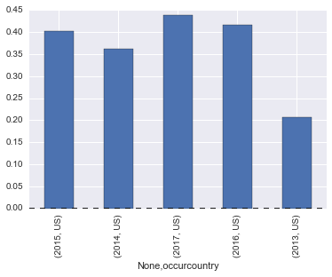

```python
dfnewUS = dfnew.iloc[dfnew.index.get_level_values('occurcountry') == 'US']
dfplotUS = dfnewUS[['RatioDeath']]
dfplotUS.plot(kind='bar',legend = False)
```

The same results for GB.

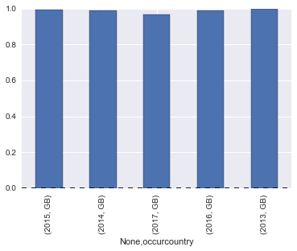

```python
dfnewUS = dfnew.iloc[dfnew.index.get_level_values('occurcountry') == 'GB']
dfplotUS = dfnewUS[['RatioDeath']]
dfplotUS.plot(kind='bar',legend = False)
```

Final comment:

```
Since the data is highly dimensional many more combinations of data can be extracted and therefore many more quesitons can be answered. I hope I could show with the above calculations, that I am able to extract these information from the given data and combine them in the right way to retrieve the answers.

I did not delete the calculations I carried out until finding the result, in order to show how I used the data and to show my thinking. For a final report, I would delete steps in between the results and would include nicer tables and graphs, which can be extracted to other forms of presentations.

I tried to give results from the calculations, but since I am not familiar with the pharma industrie, I am not able to interpret the results or judge if the results make sense.
```